# MANDATORY NOTICE OF LAYOFF, JOB SEARCH, AND EFFICIENCY*

Converted from PDF `Cederlof-MandatoryLayoffNotice-2024-QJE.pdf` · 49 pages · anchors: page `#pN`, block `#pN-bK`

Page 1

MANDAT ORY NO TICE OF LAYOFF, JOB SEARCH, AND

EFFICIENCY <sup>∗</sup>

JONAS CEDERLÖF PETER FREDRIKSSON

ARASH NEKOEI

DAVID SEIM

In all OECD countries, mandatory notice (MN) policies require firms to inform workers in advance of a layoff. In our theoretical framework, MN helps workers avoid unemployment and find better jobs by encouraging them to search for a new

job while still employed, thereby increasing future production. The magnitude of this production gain depends on the relative effectiveness of search while em- ployed versus unemployed. But on-the-job search and diminished work incentives

reduce current production. If future gains outweigh current production losses, longer advance notice improves production efficiency. If not, Coasian bargaining predicts that firms offer a larger severance instead of longer notice . W ith bargain-

ing, the sole efficiency loss of MN is due to delayed separations of unproductive job matches. We test these predictions using novel Swedish administrative data

on layoff notifications. Workers eligible for extended MN receive longer notice and larger severance, resulting in less exposure to nonemployment spells and higher- paying jobs. These favorable labor market outcomes are solely due to longer notice;

in contrast, larger severance delays job finding and has no impact on wages. We also show that advance notice replaces job search while unemployed with more effective search while employed. On the production side, we document a produc-

tivity drop among notified workers and estimate a production loss due to delayed separations. Using our estimates of production gains and losses to evaluate the

∗We thank Konrad Burchardi, Raj Chetty, Caroline Johansson, Kurt Mitman, Matthew Notowidigdo, Miika Päällysaho, Benjamin Schoefer, Jesse Shapiro, Jósef Sigur ð sson, Daphné Skandalis, three anonymous referees, and seminar partici- pants at ASSA Meetings 2024 and 2018, NBER Summer Institute 2020, Aarhus University, CEPR conferences in 2018 and 2022, CREST, Labor Economics Work- shop 2018, Nordic Summer Institute in Labor Economics 2018, the 10th Nordic Register Data and Economic Modeling Meeting, the UCLS annual conference, the FAIR Midw ay Conference , Central Bank of Denmark, SKILS conference 2023, University of Oxford, University of Galway, and the University of Copenhagen for constructive comments. Per Lindberg, Fabian Sinn, and Quan Cheng Xie provided excellent research assistance. Fredriksson acknowledges funding from Forte, Han- delsbanken, and Riksbankens Jubileumsfond.

C ⃝The Author(s) 2024. Published by Oxford University Press on behalf of President and Fel- lows of Harvard College. This is an Open Access article distributed under the terms of the Creative Commons Attribution License ( https://creativecommons.org/licenses/by/4.0/ ), which permits unrestricted reuse, distribution, and reproduction in any medium, provided the orig- inal work is properly cited. *The Quarterly Journal of Economics* (2024), 1–49. https://doi.org/10.1093/qje/qjae029 . Advance Access publication on October 3, 2024.

1

Page 2

2 *THE QUARTERLY JOURNAL OF ECONOMICS*

overall production efficiency, we conclude that the gains of MN seem to outweigh

the losses. *JEL codes:* J31, J33, J63, J68.

I. INTRODUCTION

A fundamental challenge for economists and policy makers alike is to design policies that help displaced workers find new jobs. The policy that has received most attention in this context is unemployment insurance (UI), which supports the unemployed while they search for a new job. Mandatory notice (MN) consti- tutes an alternative policy. MN requires employers to notify work- ers in advance of a layoff, giving them the opportunity to search for a new job while continuing to work and staying on the payroll. MN thus encourages on-the-job search rather than search during unemployment.

MN is a prevalent but understudied policy. It exists in all Organisation for Economic Co-operation and Development (OECD) countries ( OECD 2019 ). Yet the limited existing evidence is mostly related to the WARN Act of 1988 that introduced MN in the United States (see Addison and Blackburn 1994 for a sur- vey). <sup>1</sup> Many questions remain unanswered. Does MN help dis- placed workers in finding jobs? If so, how does the policy achieve that? Which behaviors of workers and firms are affected? What are the costs of the policy? How does MN compare to other policy alternatives, such as UI?

This article addresses these questions from a theoretical and an empirical perspective. We model MN as a policy that mitigates a market failure due to an information asymmetry. Crucially, our theory allows firms to avoid mandated information sharing by compensating the worker instead of providing advance no- tice (AN). Such side payments—which we refer to as severance— enhance production efficiency in our second-best setting. Our em- pirical analysis brings the theoretical insights to the data and comes in four parts. First, we study how an extension of MN influences firms’ decisions to comply with the rule and provide

1. The Worker Adjustment and Retraining Notification (WARN) Act requires large employers to provide two months of advance notice of a layoff. The United States has one of the least generous MN institutions in the OECD countries. Some states extend the federal MN, however. For example, the MN period in New York and New Jersey is 90 days.

Page 3

*MANDAT ORY NO TICE OF LAYOFF, JOB SEARCH, AND EFFICIENCY* 3

AN or pay severance. We also estimate the overall effects of the MN extension on workers’ labor market outcomes. Second, we de- compose the impact of MN into the effects of longer AN vis-à-vis larger severance. Third, we provide causal evidence on the higher effectiveness of job search while employed versus unemployed. Fourth, we offer evidence on the production loss of the policy. Fi- nally, we pull the pieces together by comparing the production efficiency gains and losses of MN.

Our theoretical model features an information asymmetry. Employers receive private information about an impending pro- ductivity decline that makes downsizing optimal. They have the option to inform workers in advance. From an efficiency perspec- tive, this option incorporates a trade-off. Notified workers search for a new job and supply less effort in the current job. Both be- haviors reduce current production, whereas intensified job search increases future production by reducing nonemployment and im- proving subsequent job quality. The magnitude of the future pro- duction gains depends on the effectiveness of search while em- ployed relative to search while unemployed. In the absence of a mandate, firms never notify workers, as they do not internalize the positive effect on workers’ future production. MN prescribes information sharing and changes the property rights over infor- mation. However, employers can bypass MN by replacing AN with severance. <sup>2</sup> A key insight of the theory is that employers share information when workers’ willingness to pay for notice exceeds firms’ current losses; otherwise, they avoid information sharing using severance. Coasian bargaining thereby undoes the ineffi- ciency created by the policy when losers can compensate the win- ners . Nevertheless , MN may still distort production by inducing firms to delay separation beyond what would be optimal. When firms can use severance to bypass the mandate, delayed separa- tion is the only production inefficiency associated with the policy.

We empirically examine these theoretical insights, using novel administrative data from Sweden on individual-level notice periods. In addition, we devise a methodology for inferring sever- ance payments from annual earnings and employment spell data, which we validate using survey data.

2. Use of bilateral agreements to replace notice with severance is legal in both Sweden and the United States. See Lagen (1982:80) om anställningsskydd, 2§ for Sweden.

Page 4

4 *THE QUARTERLY JOURNAL OF ECONOMICS*

We divide our empirical analysis into four parts. The first part of our empirical analysis exploits a discontinuity in MN eli- gibility. Workers older than 55 at the time of notification receive an MN extension according to the Swedish collective bargaining agreements. We find that the extension lengthens AN and leads to larger severance. In light of the theory, the rise of AN implies that private contracts are not efficient, while the replacement of notice by severance constitutes evidence that side payments mit- igate inefficiencies associated with information sharing. <sup>3</sup> Longer MN yields smoother transitions across jobs for displaced work- ers: they are less exposed to nonemployment and obtain jobs with higher wages. Interestingly, the MN wage gain occurs mainly among workers who transition to a new job without experiencing unemployment. MN thus increases total post-notification earn- ings through several channels: less nonemployment exposure, larger severance, and higher subsequent wages contribute 59%, 27%, and 14% to the earnings increase, respectively. The second part of our empirical analysis ventures beyond these reduced-form effects of MN and separately estimates the effects of extending AN and of larger severance. We introduce a second source of exogenous variation arising from spillovers across workers within the same layoff. In fact, displaced work- ers younger than 55 receive larger severance when laid off with coworkers who are older than 55. In practice, the individuals’ own age relative to the MN discontinuity identifies the effect of ad- vance notice, while the share of laid-off coworkers above age 55 identifies the effect of severance. Our two instrumental variables (2-IV) design indicates that AN lowers the exposure to nonem- ployment and increases future wages. By contrast, severance does not affect future wages and only lengthens nonemployment dura- tion.

Two aspects of our results are striking. First, the timing of finding a new job is unaffected by an extension of the notice pe- riod. This result contrasts sharply with the evidence from the lit- erature on UI, where more generous UI delays job-finding rates (e.g., Krueger and Meyer 2002 ). Second, the wage effect—1.7% higher wages for an additional month of AN—is an order of mag- nitude larger than the wage effect of UI duration estimated in

3. The use of severance instead of MN implies that the employer’s willingness to pay exceeds that of employees, whereas the opposite is true when MN increases AN.

Page 5

*MANDAT ORY NO TICE OF LAYOFF, JOB SEARCH, AND EFFICIENCY* 5

prior research ( Nekoei and Weber 2017 ). Based on these findings, we hypothesize that job search is more effective while employed than while unemployed.

The third part of the empirical analysis tests this hypothesis. Our 2-IV design reveals that one additional month of AN— compared with the counterfactual of one month of UI—reduces search activity and raises reemployment wages but does not de- lay job finding. These findings imply that employed job search is more effective than search when unemployed: search while em- ployed allows the worker to target high-quality jobs without a significant decline in job finding. We reach these conclusions also when comparing how effective job search is by the same individ- ual when employed versus unemployed and when exploiting two sources of exogenous variation in search incentives (one for the employed and one for the unemployed). All three research de- signs align closely with one another: the ratio of the return to job search in employment to unemployment ranges from 1.12 to 1.25, and the confidence intervals exclude unity. The fourth part of our empirical inquiry centers on the costs of MN. We first estimate the productivity loss of notice. We com- pare revenue per worker among firms that are exposed to simi- larly sized layoff shocks but differ in the mandated advance notice duration (MN eligibility) of their laid-off workers. We instrument AN duration with the duration that would have occurred if the firm had adhered to the MN rules and the last-in-first-out (LIFO) rule, which prescribes that workers should be notified in an in- verse order of seniority. <sup>4</sup> We estimate that productivity falls by roughly one-third when the worker is notified of layoff. We as- sess the production losses due to the delay of separations induced by MN and find that separations are indeed inefficiently delayed. To quantify the cost of delay, we estimate forgone earnings using variation from the LIFO rule and consecutive within-firm layoff events. We conclude that the MN extension induces a loss due to delay corresponding to around one-third of monthly earnings.

Finally, we combine all the empirical pieces using our theoretical framework to compare the production gains and losses of MN. The production gains—equivalent to 1.2 months of

4. Identifying the costs of MN requires stronger assumptions than for the benefits, since we cannot employ an age-based regression discontinuity (RD) design at the individual level. Instead, we leverage the implied variation in MN from multiple discontinuities due to the firm’s workforce composition.

Page 6

6 *THE QUARTERLY JOURNAL OF ECONOMICS*

earnings—comprise the positive wage effect and the shorter duration of nonemployment, which should be compared with the pro- ductivity losses of notice and the cost associated with the delay of layoffs. The net effect of the MN extension on average production is positive and amounts to about 30% of monthly income. A back- of-the-envelope calculation suggests that a reform that applies the MN extension to all separations would increase aggregate la- bor income by 0.25%. <sup>5</sup>

This article contributes to several strands of the literature. Theoretically, we focus on a new mechanism: MN mitigates a market failure due to information asymmetries and induces firms to share private information with its employees. The previous literature has either focused on the insurance properties of the policy (e.g., Pissarides 2001 and Ifergane 2022 ) or modeled MN as a commitment device for firms (see Kuhn 1992 ). Our theory also allows firms to circumvent MN using side payments akin to Lazear (1990) , who argues that private contracts will fully undo mandated severance in the first best. In contrast, we consider a second-best setting where the policy addresses a market failure. In such settings, private contracts only undo the policy if it is Kaldor-Hicks inefficient. Therefore, Coasian bargaining increases the efficiency of the policy and increases the scope for policy in- tervention in the second best, as opposed to being an argument against any policy intervention in the first best. Empirically, we offer direct evidence of side payments being used to undo regula- tions. To the best of our knowledge, we are the first to emphasize the importance of side payments for enhancing efficiency and to document empirically the occurrence of such transactions.

Previous empirical evidence on MN primarily relates to the introduction of the WARN Act of 1988 (see Ruhm 1992 , 1994 ; Burgess and Low 1992 ; Jones and Kuhn 1995 ). Papers in this literature mainly compare workers in firms subject to the WARN Act to workers who are not in such firms, controlling for a rich set of covariates. We extend this literature by providing new es- timates of the benefits of MN, as well as the underlying mech- anisms, using state-of-the-art quasi-experimental methods. We also contribute to a small literature that estimates productivity

5. This assumes that the estimated production gain—0.29 of monthly income—can be generalized to all separations. Under this assumption we obtain 0 *.* 29 × 0 *.* 87% = 0 *.* 25% , where 0.87% is the monthly separation rate for Sweden estimated by Hobijn and Sahin (2009) .

Page 7

*MANDAT ORY NO TICE OF LAYOFF, JOB SEARCH, AND EFFICIENCY* 7

losses of MN. Kuhn and Yu (2021) find that team productivity falls during the notice period, while Alfitian and Vogelsang (2022) document that laid-off workers’ absenteeism rises sharply around the time of notification. By focusing on firm revenue, our approach estimates the overall costs of MN. Our findings on the effective- ness of on-the-job search complement Blau and Robins (1990) and Faberman et al. (2022) . An advantage of their evidence is that they use surveys that ask about the offer arrival rate. In com- parison to this literature, our estimates are arguably more robust to compositional differences across the employed and the unem- ployed.

The article unfolds as follows. Section II provides the conceptual framework that guides our empirical analysis. Section III describes the institutional setting and the data. Section IV pro- vides our empirical analysis of the benefits of MN. We separate the causal effects of advance notice and severance in this section. Section V offers estimates of the relative effectiveness of search- ing from employment compared with unemployment. Section VI contains our empirical analysis of the costs of MN. Section VII connects the empirical results to the theory and calculates the net impact on production of MN. Section VIII concludes.

II. CONCEPTUAL FRAMEWORK

We examine how MN influences the behaviors of workers and firms, with a particular focus on production efficiency. We concep- tualize MN as a remedy for a market failure that results from information asymmetry. MN encourages certain firms to share information, while others sidestep the mandate through bilateral agreements that compensate workers for the loss of AN. In this context, we demonstrate that MN has the potential to enhance efficiency.

That mandated information sharing can improve productive efficiency is an idea with broad applicability. We start with an abstract example that illustrates the essence of the idea. It also highlights its relevance to other contexts, such as bankruptcy laws that mandate timely information sharing with investors.

Page 8

8 *THE QUARTERLY JOURNAL OF ECONOMICS*

We apply this general idea to the case where the firm has private information of an impending layoff. We convey the main message as simply as possible, relegating the details and exten- sions to Online Appendix A.

*II.A. The Setting*

Consider a two-period model. At the beginning of the first period, every worker is matched with an employer. At that mo- ment, wages are set and remain fixed for both periods with no possibility of renegotiation. There is free entry of employers, so a zero-profit condition determines wages. It is common knowledge that productivity in the second period may fall by a factor of *z* with probability *θ*. The combination of a fixed wage and stochas- tic productivity leads to the possibility of layoff in response to a productivity fall, as in Blanchard and Tirole (2008) .

Just after setting wages, the employer receives private information about the productivity of the match in the second period. The information is verifiable, so the employer may share it with the worker by providing AN at the start of the first period.

A notified worker searches on the job during the first period. She applies to one job, knowing that the likelihood of getting the job is decreasing in the wage: *λ<sup>e</sup>* = *φ<sup>e</sup>* ( *w* ) , where *w* denotes the target w age . On-the-job-search by the notified worker, combined with the lower incentive to exert effort (shirking), reduces first- period productivity in the notifying firm by a factor of *α*. There is heterogeneity in *α* across firms. Before the start of the second period, the laid-off worker searches for a new job with the job- finding rate of *λ<sup>u</sup>* = *φ<sup>u</sup>* ( *w* ) . <sup>7</sup>

6. We thus assume that expected utility is positive: ( 1 −*θ*) *y* 2 + *θy* <sup>′</sup> 2 *<sup>></sup>* <sup>0</sup> <sup>.</sup> 7. There is a close connection between the directed search model here and a model with random search. For example, a directed search model with a job- finding rate that is linear in the target w age , *φ* ( *w* ) = 2 ( 1 −*w* ) and a random search model with offers from a uniform distribution imply the same expected

Page 9

*MANDAT ORY NO TICE OF LAYOFF, JOB SEARCH, AND EFFICIENCY* 9

We parameterize the difference in the likelihood of finding a job between the employed and unemployed as *φ<sup>u</sup>* ( *w* ) = *φ* ( *w,* 0 ) and *φ<sup>e</sup>* ( *w* ) = *φ* ( *w, η*) , where *<sup>∂φ</sup>*

*∂w <sup><</sup>* <sup>0</sup> <sup>.</sup> <sup>We</sup> <sup>assume</sup> *<sup>∂φ</sup>*

**equation / math rendering (image)**

NOTE: contains mathematical notation; text above is the PDF text layer and symbols may be mis-extracted. Image shows the original.

*∂η <sup>></sup>* <sup>0</sup> <sup>,</sup> <sup>so</sup> <sup>that</sup> *<sup>η</sup>* captures the relative effectiveness of employed and unemployed search. There is heterogeneity in *η* across individuals. <sup>8</sup>

Because our focus is on production efficiency, we take workers to be risk neutral. Another assumption is that private contracts do not include AN. <sup>9</sup> This assumption is analogous to the UI lit- erature ( Baily 1978 ; Chetty 2006 ), where private contracts do not include UI. In keeping with the UI literature, we take as given the existence of frictions that prevent the optimal provision of notice in private contracts and examine whether MN improves outcomes in the second best. <sup>10</sup> We show empirically that MN increases the notice period, which supports the assumption that private con- tracts are not optimal.

*II.B. MN Effect on AN and Severance*

In the absence of MN, the equilibrium wage is *w* = *y* . Firms alwa ys la y off workers between the two periods, in case produc- tivity drops in the second period. As such, separation is efficient. But no firm provides notice, and this decision may be inefficient. Firms choose not to notify the worker because they bear the entire cost of notification and do not internalize the benefit to workers. The cost to firms is *αy* , that is, the reduction in the productiv- ity due to notification, and the benefit to workers is the expected increase in utility, which we denote by *σ* ≡*U <sup>n</sup>* −*U <sup>u</sup>* . The hetero- geneity in the effectiveness of employed search ( *η*) implies hetero- geneous *σ*. The decision to not provide notice is inefficient when the benefit to the worker outweighs the cost to the firm, *σ > αy* . This inefficiency may justify policy intervention.

In the presence of MN, the firm has three options. One option is to comply with the mandate and notify the worker. This reduces

job quality and job-finding rate. This equivalence is a general feature of the two models ( Nekoei and Weber 2017 ).

8. For convenience, we restrict the space of heterogeneity so that a nonnotified worker (given her prior) does not search in the first period.

9. Our findings remain unchanged when the contract space includes severance. In addition, since all agents in the economy are risk neutral, we ignore UI.

10. A way to rationalize the inefficiency in private contracts is to assume that workers overestimate the stability of their jobs; while we lack direct empirical evidence on such behavior, the results in Spinnewijn (2015) suggest that the un- employed are overly optimistic regarding their employment prospects.

Page 10

10 *THE QUARTERLY JOURNAL OF ECONOMICS*

profit by *αy* due to the lower productivity of notified workers. Another option is to disregard the mandate and instead compensate the worker ex post by paying severance. The amount of severance is equivalent to the gain to the worker from notice, *σ.* The firm thus provides notice if *σ > αy* , and sidesteps the mandate by us- ing severance when *σ < αy* , that is, it shares information when it is efficient.

But there is an efficiency loss associated with the policy. A distressed firm also has the option of delaying the layoff to avoid the productivity loss of notice during the high-productivity period. Delayed separation is a loss, since it would be efficient to separate at the start of the second period if productivity falls.

In equilibrium, the firm’s choice of layoff policy must be incentive compatible, conditional on the w age . The equilibrium w age , and the implied layoff policy, is pinned down by free en- try. We show in Online Appendix A that the firm’s optimization problem can be thought of as choosing the option which has mini- mum cost, where the cost associated with each course of action is *κ<sup>N</sup>* = *αy* , *κ<sup>S</sup>* = *σ*, and *κ<sup>D</sup>* =

1 −*<sup>θ</sup>* 2

**equation / math rendering (image)**

NOTE: contains mathematical notation; text above is the PDF text layer and symbols may be mis-extracted. Image shows the original.

*zy* , where the superscripts denote the three options: *N* for notification, *S* for paying severance, and *D* for delay.

The likelihood that the firm will delay notice is increasing in the productivity loss of notice, and decreasing in the size of the productivity shock. <sup>11</sup> We denote the set of firms that provide notice, pay severance, or delay separation by *<sup>i</sup>* =

min

*κ<sup>N</sup> , κ<sup>S</sup> , κ<sup>D</sup>*

**equation / math rendering (image)**

NOTE: contains mathematical notation; text above is the PDF text layer and symbols may be mis-extracted. Image shows the original.

= *κ<sup>i</sup>*

**equation / math rendering (image)**

NOTE: contains mathematical notation; text above is the PDF text layer and symbols may be mis-extracted. Image shows the original.

and their share by *P <sup>i</sup>* = *μ*

*<sup>i</sup>*

for *i* ∈

*N, S, D*

**equation / math rendering (image)**

NOTE: contains mathematical notation; text above is the PDF text layer and symbols may be mis-extracted. Image shows the original.

, where the distribution of types ( *α, σ* ) is a measure *μ*.

*II.C. MN Effect on Wages, Employment, Earnings, and*

*Production*

An unemployed worker chooses the target wage to maximize expected utility, *U <sup>u</sup>* = *λ<sup>u</sup> w <sup>u</sup>* + ( 1 −*λ<sup>u</sup>* ) *b*, where *b* denotes home production. <sup>12</sup> Notified workers choose a target wage to maximize utility, knowing that if they do not find a job while employed, they can search again as unemployed, *U <sup>n</sup>* = *λ<sup>e</sup> w <sup>e</sup>* + ( 1 −*λ<sup>e</sup>* ) *U <sup>u</sup>* . The employment rate among notified workers in the second

11. Our RD estimates will not capture equilibrium wage adjustments. In partial equilibrium with exogenous wages, the cost associated with delay can be writ- ten as *κ<sup>D</sup>* = *w* −( 1 −*z* ) *y* .

12. We assume that layoff is optimal after a productivity drop, that is, *U <sup>u</sup> >* ( 1 −*z* ) *y* .

Page 11

*MANDAT ORY NO TICE OF LAYOFF, JOB SEARCH, AND EFFICIENCY* 11

period equals *λ<sup>n</sup>* = *λ<sup>e</sup>* + ( 1 −*λ<sup>e</sup>* ) *λ<sup>u</sup>* , and the expected wage in the new job is *w <sup>n</sup>* = <sup>1</sup>

**equation / math rendering (image)**

NOTE: contains mathematical notation; text above is the PDF text layer and symbols may be mis-extracted. Image shows the original.

1. *Wage Effect.* The introduction of MN increases the expected reemployment wage by *w* ≡*w <sup>n</sup>* −*w <sup>u</sup>* for workers who are notified, that is, workers who belong to *<sup>N</sup>* . We decompose this w age increase , using linear approximation, into two components. One component is due to the relative effectiveness of employed job search, the other is due to notified workers having an extended search period:

*w* ≃ <sup>1</sup>

**equation / math rendering (image)**

NOTE: contains mathematical notation; text above is the PDF text layer and symbols may be mis-extracted. Image shows the original.

*ξ*

**equation / math rendering (image)**

NOTE: contains mathematical notation; text above is the PDF text layer and symbols may be mis-extracted. Image shows the original.

*λ<sup>e</sup>*

**equation / math rendering (image)**

NOTE: contains mathematical notation; text above is the PDF text layer and symbols may be mis-extracted. Image shows the original.

*λ<sup>n</sup>*

**equation / math rendering (image)**

NOTE: contains mathematical notation; text above is the PDF text layer and symbols may be mis-extracted. Image shows the original.

⎡

**equation / math rendering (image)**

NOTE: contains mathematical notation; text above is the PDF text layer and symbols may be mis-extracted. Image shows the original.

⎢ ⎢ ⎢ ⎣ *η<sup>∂φ</sup>*

**equation / math rendering (image)**

NOTE: contains mathematical notation; text above is the PDF text layer and symbols may be mis-extracted. Image shows the original.

*∂η* Relative effectiveness

−

**equation / math rendering (image)**

NOTE: contains mathematical notation; text above is the PDF text layer and symbols may be mis-extracted. Image shows the original.

*U <sup>u</sup>* −*b*

*∂φ*

**equation / math rendering (image)**

NOTE: contains mathematical notation; text above is the PDF text layer and symbols may be mis-extracted. Image shows the original.

*∂w* Extended search

⎤

**equation / math rendering (image)**

NOTE: contains mathematical notation; text above is the PDF text layer and symbols may be mis-extracted. Image shows the original.

⎥ ⎥ ⎥ ⎦ *<sup>,</sup>* (1)

**equation / math rendering (image)**

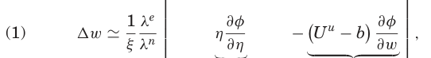

NOTE: contains mathematical notation; text above is the PDF text layer and symbols may be mis-extracted. Image shows the original.

where *ξ >* 0 denotes the negative of the second-order condition for worker optimization. If employed search is more effective ( *η >* 0 ), notification unambiguously improves outcomes. Otherwise, noti- fication involves two countervailing forces: it induces workers to seek higher-wage jobs while employed, but reduces wages by in- creasing the likelihood of unemployment search.

2. *Employment Effect.* For workers who are given notice, the introduction of MN changes the exposure to unemployment by *λ* ≡*λ<sup>n</sup>* −*λ<sup>u</sup>* , which can be decomposed in a similar fashion as above. One component is due to an to extended period of search, that is *λ<sup>u</sup>* ( 1 −*λ<sup>u</sup>* ) . The other component is due to the relative ef- fectiveness of employed job search, *λ<sup>e</sup>* −*λ<sup>u</sup>* . We thus have

*λ* ≃ *λ<sup>u</sup>*

**equation / math rendering (image)**

NOTE: contains mathematical notation; text above is the PDF text layer and symbols may be mis-extracted. Image shows the original.

1 −*λ<sup>u</sup>*

**equation / math rendering (image)**

NOTE: contains mathematical notation; text above is the PDF text layer and symbols may be mis-extracted. Image shows the original.

Extended search

+

**equation / math rendering (image)**

NOTE: contains mathematical notation; text above is the PDF text layer and symbols may be mis-extracted. Image shows the original.

*η<sup>∂φ</sup>*

**equation / math rendering (image)**

NOTE: contains mathematical notation; text above is the PDF text layer and symbols may be mis-extracted. Image shows the original.

*∂η* <sup>+</sup>

**equation / math rendering (image)**

NOTE: contains mathematical notation; text above is the PDF text layer and symbols may be mis-extracted. Image shows the original.

*w <sup>e</sup>* −*w <sup>u</sup> <sup>∂φ</sup>*

**equation / math rendering (image)**

NOTE: contains mathematical notation; text above is the PDF text layer and symbols may be mis-extracted. Image shows the original.

*∂w*

**equation / math rendering (image)**

NOTE: contains mathematical notation; text above is the PDF text layer and symbols may be mis-extracted. Image shows the original.

Relative effectiveness

1 −*λ<sup>u</sup> .* (2)

**equation / math rendering (image)**

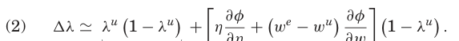

NOTE: contains mathematical notation; text above is the PDF text layer and symbols may be mis-extracted. Image shows the original.

Note that *λ<sup>e</sup>* −*λ<sup>u</sup>* is ambiguous in sign, even if *η >* 0 , because advance notice encourages workers to target higher-quality jobs, thus reducing the job-finding rate.

3. *Earnings Effect.* MN affects earnings ( *Y* ) by increasing the income of those who receive notice, by severance payments, and by changing the income of workers with delayed separation,

Page 12

12 *THE QUARTERLY JOURNAL OF ECONOMICS*

that is

*Y* =

**equation / math rendering (image)**

NOTE: contains mathematical notation; text above is the PDF text layer and symbols may be mis-extracted. Image shows the original.

*λ<sup>n</sup> w <sup>n</sup>* −*λ<sup>u</sup> w <sup>u</sup>*

**equation / math rendering (image)**

NOTE: contains mathematical notation; text above is the PDF text layer and symbols may be mis-extracted. Image shows the original.

*P <sup>N</sup>* Increased notice

+ *σP <sup>S</sup>* Increased severance

+

**equation / math rendering (image)**

NOTE: contains mathematical notation; text above is the PDF text layer and symbols may be mis-extracted. Image shows the original.

*w <sup>D</sup>* −*λ<sup>u</sup> w <sup>u</sup>*

**equation / math rendering (image)**

NOTE: contains mathematical notation; text above is the PDF text layer and symbols may be mis-extracted. Image shows the original.

*P <sup>D</sup>* Dela yed la yoff

*,* (3)

where *w <sup>D</sup>* = **E** (*w*| *<sup>D</sup>* ) is the average wage in firms that delay notice in response to the mandate. In the Online Appendix , we show how the effect of MN on earnings can be decomposed into four in- tuitive components that can be estimated separately, that is,

*Y*

*w <sup>N</sup>* <sup>≃</sup> −*NE* Non-employment dur. effect

−

**equation / math rendering (image)**

NOTE: contains mathematical notation; text above is the PDF text layer and symbols may be mis-extracted. Image shows the original.

*w N* −*w u*

**equation / math rendering (image)**

NOTE: contains mathematical notation; text above is the PDF text layer and symbols may be mis-extracted. Image shows the original.

*w <sup>N</sup>*

**equation / math rendering (image)**

NOTE: contains mathematical notation; text above is the PDF text layer and symbols may be mis-extracted. Image shows the original.

*L* New job dur. effect

+ *λ<sup>n</sup> <sup>w</sup>*

**equation / math rendering (image)**

NOTE: contains mathematical notation; text above is the PDF text layer and symbols may be mis-extracted. Image shows the original.

*w <sup>N</sup> <sup>P</sup> <sup>N</sup>*

Wage effect

+ *σ w <sup>N</sup> <sup>P</sup> <sup>S</sup>*

**equation / math rendering (image)**

NOTE: contains mathematical notation; text above is the PDF text layer and symbols may be mis-extracted. Image shows the original.

Severance effect

*,* (4)

where *NE* denotes nonemployment duration and *L* the duration on the new job. The new job duration effect arises because the new job yields a lower wage due to the displacement effect.

4. *Effects on Aggregate Production and Social Welfare.* In general equilibrium, aggregate market production equals labor income, while utilitarian social welfare is the sum of aggregate (market) production and home production. <sup>13</sup> To examine the MN effect on welfare, we extend our model in the Online Appendix to allow for a mixed strategy for firms. The firm chooses the proba- bility of sharing information, given the mandated minimum prob- ability ( *m* ). This extension also enables us to study a marginal MN extension on production and welfare and thus the optimal duration of the mandate and production efficiency.

A marginal MN extension has two effects on welfare. First, it extends AN for the subset of the population already receiving no- tice (inframarginal effect). Second, because the cost of providing notice increases, marginal workers are transferred across states: some marginal workers are not receiving notice anymore, and are thus moved from state *N* to states *S* and *D* , while other marginal

13. Recall that we assume risk-neutral agents and abstract from disutility of search and work.

Page 13

*MANDAT ORY NO TICE OF LAYOFF, JOB SEARCH, AND EFFICIENCY* 13

workers are moved from state *S* to *D* , that is, from receiving severance to experiencing a delay in notification.

At the margin, moves from notification to severance are not relevant as severance compensates the worker exactly. The same is not true for the marginal workers who are pushed from notice or severance to delay, where there is a discontinuous reduction in welfare as delays are inefficient. The impact on social welfare ( *V* ) of a marginal extension of MN can be written as:

*dV dm* <sup>=</sup> *P <sup>N</sup>* **E**

*σ* −*αy* | *<sup>N</sup>*

**equation / math rendering (image)**

NOTE: contains mathematical notation; text above is the PDF text layer and symbols may be mis-extracted. Image shows the original.

Net production gain of info sharing

Infra-marginal

−*<sup>∂</sup><sup>P</sup> <sup>D</sup>*

**equation / math rendering (image)**

NOTE: contains mathematical notation; text above is the PDF text layer and symbols may be mis-extracted. Image shows the original.

*∂m* **<sup>E</sup>**

**equation / math rendering (image)**

NOTE: contains mathematical notation; text above is the PDF text layer and symbols may be mis-extracted. Image shows the original.

*w* −*w <sup>D</sup>* | *∂ <sup>D</sup>*

**equation / math rendering (image)**

NOTE: contains mathematical notation; text above is the PDF text layer and symbols may be mis-extracted. Image shows the original.

Net production loss of delaying

Marginal

*,* (5)

where *w* denotes expected post-displacement production (includ- ing home production) for marginal workers and *∂ <sup>D</sup>* the bound- ary of delay. The first term on the right side is unambiguously positive since notice is given when *σ* ⩾ *αy* . In other words, firms provide notice if and only if information sharing is production ef- ficient. The ability of firms to pay severance is crucial: although the payment of severance has no effects on aggregate production, the possibility of paying severance implies that firms avoid inef- ficient notice. The second term on the right side is negative since separation is efficient in the second period.

In the remainder of the article, we add empirical content to this conceptual framework. One major objective of the empiri- cal analysis is to examine whether firms respond to MN by pay- ing severance—a key component in the efficiency case for MN ( Section IV.A ). Section IV.A also provides estimates of the wage and employment effects of MN ( equations (1) and (2) ). Section V offers direct evidence on the relative effectiveness of searching from employment compared to unemployment. In Section IV.A , we estimate the overall earnings effect ( equation (3) ) and decom- pose it by estimating all components of the right side of equation (4) . Section VII uses equation (5) as a basis for evaluating the production effects of MN; we compare an estimate of the expected production gain from giving advance notice with an estimate of the productivity drop associated with having workers on notice, as well as the production loss of delay. In our empirical exercise, we proxy *w* with expected earnings; we thus ignore home produc- tion and focus on the effects of MN on production efficiency.

Page 14

14 *THE QUARTERLY JOURNAL OF ECONOMICS*

III. INSTITUTIONAL SETTING AND DA T A

*III.A. Institutional Setting*

The Swedish Employment Protection Law (Lag 1982:80 om anställningsskydd, 8§) stipulates that a firm intending to lay off a worker must give written notice to the worker in advance. The length of the MN period increases discontinuously with tenure, from a minimum of 1 month for employees with less than 2 years of tenure, to a maximum of 6 months for workers with at least 10 years of tenure. Alternative rules can be negotiated in col- lective bargaining agreements. For instance, many white-collar agreements in the private sector stipulate that workers above age 55 with 10 years of tenure get an additional 6 months of no- tice. <sup>14</sup> Neither the law nor these agreements include mandatory severance. That said, notified workers may agree to compensa- tion packages involving AN and severance if they are perceived as more generous than the default rules. The typical configuration is that the union negotiates with the employer on behalf of its work- ers to arrive at packages that may be tailored specifically to each employee. Moreover, workers with at least 6 months of tenure are eligible for 60 weeks of UI, replacing 80% of their earnings (up to a cap) when unemployed.

Ideally, we would match the information on notice periods from the collective agreements to notified individuals. However, our micro data do not include information on which collective agreement a worker belongs to at a given point in time. In our main empirical analyses, we focus on the age 55 threshold for all white-collar workers in the private sector, because age is more precisely measured than tenure in our data. In auxiliary analy- ses, we also use variation from the tenure thresholds.

A firm planning to lay off at least five workers at the same plant within three months must report to the Public Employment Service (PES). The firm first reports the number of workers it in- tends to lay off, along with the reason for downsizing. Upon this initial report, the firm starts to negotiate with the labor unions over whom to lay off, respecting the LIFO rule that requires work- ers with shorter tenure to be laid off first conditional on occupa- tion type ( Cederlöf 2024 ). The endpoint of the negotiations is the

14. We have hand-collected information from all major collective agreements in the Swedish labor market for the relevant time period (2005–2016). Other age rules do exist, but they are much less prevalent.

Page 15

*MANDAT ORY NO TICE OF LAYOFF, JOB SEARCH, AND EFFICIENCY* 15

compilation of a list of workers who would be notified with their specific layoff dates. This list must be submitted to the PES at least 2 months before the first displacement date, and on aver- age, it arrives 2.5 months after the initial layoff report.

*III.B. Data and Estimation Sample*

Our main data source is the administrative register of all notifications reported to the PES during 2005–2016 ( Public Employment Service 2024a ). For each worker, we measure the de facto AN period as the duration between the notification date and the reported displacement date. <sup>15</sup> We assume that the notification date is also the date the worker learns about her future displace- ment. Our evidence on worker search behavior (see Section V , Figure V ) is consistent with this assumption.

We match the notification register with six other administrative data sets: (i) RAMS ( Statistics Sweden 2024a ) contains the universe of matches between employers and employees, and in- cludes information on earnings and employment spells; (ii) LISA ( Statistics Sweden 2019 ) contains individual-level characteris- tics; (iii) the Wage Survey ( Statistics Sweden 2024b ) comprises the employer-provided full-time-equivalent monthly w age , mea- sured in September–November for all workers in the public sector and around half of all private-sector workers. The wage measure includes all fixed-wage components, as well as piece rates, perfor- mance pay, and fringe benefits; (iv) the Unemployment Spell Reg- ister ( Public Employment Service 2024b ) from the PES provides the duration of unemployment spells and information on contacts with the PES caseworkers; (v) the Income Statement and Balance Sheet Register ( Statistics Sweden 2024c ) contains information on firms’ revenue, value added, and profits; and (vi) the Labor Force Survey (LFS, Statistics Sweden 2024d ) contains information on individuals’ labor market status and job search for a 0.4% sam- ple of the population aged 15–74. The availability of all of these data sources extends beyond the 2005–2016 period covered by the notification register, such that we can observe both pre- and post- notification outcomes.

1. *Population and Descriptive Statistics.* Our population comprises all individuals who were Swedish residents at some

15. For 84% of workers, the individual notification date corresponds to the arrival of the list at the PES.

Page 16

16 *THE QUARTERLY JOURNAL OF ECONOMICS*

point during 2005–2016. As our first research design exploits a discontinuity in MN at age 55, the baseline estimation sample re- stricts attention to white-collar workers who are present in the notification register and are aged 52–58 at the time of layoff. We also remove workers laid off in bankruptcy events, since the col- lective bargaining agreements do not apply in those cases.

Table I presents descriptive statistics for notified workers overall (column (1)); notified workers in the baseline estimation sample (column (2)), and for two comparison groups (all workers in column (3) and all workers reweighting the industry shares to match notified workers in column (4)). Panel A shows individual- level characteristics, and Panel B presents firm-level statistics.

Notified individuals differ substantially from employed workers in almost all dimensions (compare columns (1) and (3)). How- ever, most of these differences are driven by notifications being more common in certain industries, such as manufacturing and construction. When we control for industry—compare columns (1) and (4)—only two differences remain. First, firm size differs across the two columns because data contain notifications involv- ing at least five workers. Second, educational attainment is lower among the notified reflecting the known fact that lower-educated workers have a higher layoff risk. The individuals in our estima- tion sample have higher wages, earnings, and educational attain- ment than the average notified individual (compare columns (1) and (2)).

IV. BENEFITS OF MN

*IV.A. Estimating the Effect of MN Using an RD Design*

Our first identification strategy exploits the discontinuity in the length of MN at age 55 for white-collar workers in the private sector using the following equation:

*y i* = *β***1**

**equation / math rendering (image)**

NOTE: contains mathematical notation; text above is the PDF text layer and symbols may be mis-extracted. Image shows the original.

*A i* ⩾ 55

+ *g* <sup>0</sup>

**equation / math rendering (image)**

NOTE: contains mathematical notation; text above is the PDF text layer and symbols may be mis-extracted. Image shows the original.

*A i* −55

+ **1**

**equation / math rendering (image)**

NOTE: contains mathematical notation; text above is the PDF text layer and symbols may be mis-extracted. Image shows the original.

*A i* ⩾ 55

× *g* <sup>1</sup>

**equation / math rendering (image)**

NOTE: contains mathematical notation; text above is the PDF text layer and symbols may be mis-extracted. Image shows the original.

*A i* −55

+ *δ***X i** + *ε i ,* (6)

**equation / math rendering (image)**

NOTE: contains mathematical notation; text above is the PDF text layer and symbols may be mis-extracted. Image shows the original.

where **1** (·) denotes the indicator function, *A i* age at notification for individual *i* , and *g <sup>k</sup>* (*.* ) , *k* = 0 *,* 1 , are age control functions. Our main analysis uses data for individuals who are aged ±3 years relative to the age 55 threshold. This corresponds closely to the optimal bandwidth according to Calonico, Cattaneo, and Titiunik (2014) (see Online Appendix II.B). Since age is discretely mea-

Page 17

*MANDAT ORY NO TICE OF LAYOFF, JOB SEARCH, AND EFFICIENCY* 17

TABLE I DESCRIPTIVE ST A TISTICS

[output not shown]

NOTE: table converted from PDF layout to HTML text; cell boundaries are reconstructed. See PDF if exact alignment matters.

*Notes.* The table presents summary statistics (means) for different samples over the years 2005–2016. Column (1) considers all notified individuals, and column (2) notified individuals in our main analysis sample— white-collar workers in the private sector aged 52–58 at the time of notification. Column (3) shows char- acteristics for a stratified random sample of employed workers. We create the sample as follows. First, we compute the share of notified workers in each calendar year from the population in column (1). We extract a random sample of workers from the matched employer-employee data using the shares across years from the first step as weights. In column (4), we further reweight observations so that the industry distribution of employed workers matches that of notified workers in column (1) (using the 11 industry-categories in the table). Immigrant is an indicator for being born outside Sweden. Age and tenure are measured at notification in columns (1) and (2) and at the end of the year for columns (3) and (4). Earnings in *t* −1 correspond to an- nual earnings in the previous calendar year. The wage is the full-time equivalent monthly wage, taken from the Wage Survey, and is observed in September–October each year for all public-sector workers and roughly 50% of all private-sector employees. Firm-level characteristics are computed at the individual level, except firm size, where the unit of observation is a firm.

Page 18

18 *THE QUARTERLY JOURNAL OF ECONOMICS*

sured in months, we rely on a parametric control function. <sup>16</sup> Our default specification has a linear control function interacted with the threshold. In addition, **X i** controls for a number of predeter- mined covariates and month-by-year fixed effects to increase pre- cision.

The estimated *β* of equation (6) represents the effect of longer MN on outcomes, given the absence of (i) other laws featuring a discontinuity at age 55 at the time of notification (exclusion re- striction) and (ii) manipulation of age at notification (random as- signment). Online Appendix II.A shows both that the distribution of notified individuals is smooth and that predetermined covari- ates are balanced around the threshold.

1. *MN Effect on AN and Severance.* We investigate the effect of the MN extension on AN or, in other words, the effect of de jure notice on de facto notice. Figure I , Panel A shows that be- ing just above age 55 at the time of notification increases AN by about 2.6 months from a base of 6.7 months. The observed pos- itive effect of MN on AN indicates that private contracts do not incorporate efficient notice, as in the model of Section II . Accord- ing to the model, the observed increase in AN implies that MN has enhanced production efficiency.

Controlling for baseline covariates and displacement event fixed effects changes the point estimates only marginally ( Online Appendix Table 6), suggesting that baseline characteristics are similar on either side of the threshold within and across no- tifications ( Online Appendix Table 1). However, a more flexi- ble polynomial control function in age at notification reduces the point estimate. For instance, when controlling for a second- order polynomial, the discontinuity estimate falls by a month. Online Appendix C shows that this reduction is an artifact of measurement error in notification dates, which translates into measurement error in age at notification. <sup>17</sup> Online Appendix C

16. Since we observe month of birth rather than day of birth, we cannot determine whether someone who turns 55 in the notification month is above 55 or just below 55. We therefore exclude observations exactly at the cut-off.

17. Online Appendix C further analyzes the consequences of measurement error. It shows, inter alia, that measurement error in notification dates makes a discontinuity look like a nonlinearity (as observed in Figure I , Panel A). More- over, measurement error in the assignment variable complicates a nonparamet- ric RD approach. Intuitively, as measurement error increases, the relationship appears to be more nonlinear close to the threshold, which erroneously reduces

Page 19

*MANDAT ORY NO TICE OF LAYOFF, JOB SEARCH, AND EFFICIENCY* 19

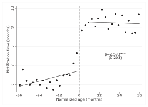

NOTE: figure/graphic rendered as an image from the PDF; its content is not machine-readable text. Caption (if any) follows as the next block.

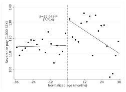

NOTE: figure/graphic rendered as an image from the PDF; its content is not machine-readable text. Caption (if any) follows as the next block.

FIGURE I

The Effect of Mandated Notice (MN) on Actual Notification Times and Severance

Pay

The figure plots (A) the advance notification (AN) period, (B) severance on the *y* -axis against age at notification relative to the 55 threshold in two-month bins on the *x* -axis. Severance pay is measured as excess earnings in the year of displace- ment (see Section IV.A ). The regression lines come from estimating equation (6) with a linear age polynomial interacted with the threshold indicator for individu- als aged 52–58 at the time of notification. The regressions also include individual- level baseline covariates (earnings in the year prior to notification, gender, im- migrant status, tenure at notification, educational attainment fixed effects), and month-by-year fixed effects. The estimated discontinuity at the threshold and its standard error are reported. Standard errors are clustered by notification event. <sup>∗</sup> *p <* .1, <sup>∗∗</sup>*p <* .05, <sup>∗∗∗</sup>*p <* .01.

also shows that the parametric RD design is less susceptible to the measurement error problem. Because of these issues, we esti- mate a linear interacted control function.

The conceptual framework outlined in Section II suggests that MN will be substituted by severance pay when losses to firms from having workers on notice exceed the compensation de- manded by workers. We test this prediction by examining the ef- fect of longer MN on severance.

Measuring severance is a major challenge in any tax-based administrative data. Because severance is taxed as labor earn- ings, it is reported together with other earnings. We overcome this challenge as follows: we initially predict the portion of an- nual earnings due to regular wage payments in the year of

selected optimal bandwidths. Nonparametric RD thus places greater emphasis on the portion of the data that is most affected by the measurement error. Finally, Online Appendix C also includes donut RD estimates, which, as intuition suggests, tend to be larger in absolute value than the conventional RD estimates because the donut RD discards the portion of the data most affected by measurement error.

Page 20

20 *THE QUARTERLY JOURNAL OF ECONOMICS*

separation. Severance is then measured as annual earnings net of the predicted annual wage payments. For example, if a worker separates in April, we construct severance by subtracting four months of monthly earnings—imputed from the previous year, adjusted for average growth in the economy—from total earnings received from the displacing employer.

We validate the imputed severance by comparing it to survey data where firms report total severance payments made to their employees. Imputed and reported severance are strongly and pos- itively correlated (see Online Appendix Figure 10). When regress- ing imputed severance on reported severance we obtain a coeffi- cient of 1.07 (std. err. 0.012). Imputed severance slightly over- estimates reported severance, presumably because the imputed measure includes other components that are paid out at the end of the spell, such as accumulated overtime. When estimating the effect of MN on severance, this discrepancy is not an issue since the additional payments are balanced around the threshold.

Figure I , Panel B shows that severance increases by 17 kSEK at the age 55 threshold, corresponding to 53% of a monthly w age . <sup>18</sup> Agents thus make private agreements to partially undo public regulation, providing empirical support to the theoretical conjecture of Lazear (1990) .

2. *MN Effect on Employment Status.* Figure II examines how MN affects the transition process for workers in general and whether longer MN shields workers from nonemployment in particular. Panel A illustrates overall labor market dynamics for workers aged 52–58 by showing the share in different states over time relative to notification. Workers begin to leave the firm upon notice, and around half of all notified workers are in new jobs or in nonemployment after six months. Eleven percent of all notified still work at the notifying firm within two years after notification.

Panel B focuses on the same labor market states but plots RD estimates, that is, the causal effects of longer MN on the likeli- hood of being in different states, along with 95% confidence inter- vals. Longer MN increases the likelihood of remaining at the no- tifying firm in the first year after notice. The effects are strongest

18. All amounts have been deflated to 2010 values. In February 2024, the conversion rates are 10.29 SEK/dollar and 11.17 SEK/euro. Online Appendix Figure 13 shows the result of a permutation test where we vary the age threshold. The one-sided *p* -value associated with the actual threshold at age 55 is .014.

Page 21

*MANDAT ORY NO TICE OF LAYOFF, JOB SEARCH, AND EFFICIENCY* 21

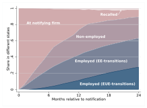

NOTE: figure/graphic rendered as an image from the PDF; its content is not machine-readable text. Caption (if any) follows as the next block.

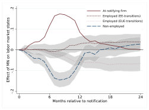

NOTE: figure/graphic rendered as an image from the PDF; its content is not machine-readable text. Caption (if any) follows as the next block.

FIGURE II

Dynamic Employment Transitions

The figure presents employment outcomes over time relative to notification for individuals aged 52–58 at the time of notification. Panel A shows the employment dynamics after notification where we treat new employment as an absorbing state. Notified workers who are employed are split into those who made an employment- to-employment transition (EE) and those who had a period of nonemployment be- tween the spells (EUE). An individual who experiences a period of nonemployment and returns to the notifying firm is coded as a recall. Panel B plots RD estimates and 95% confidence intervals (in gray) corresponding to equation (6) at each point in time after notification. Standard errors are clustered by notification event. Re- gressions include a linear age control function where the slope is allowed to differ above and below the threshold, baseline covariates (earnings in the year prior to notification, gender, immigrant status, tenure, educational attainment fixed ef- fects), and month-by-year fixed effects.

after six months, which corresponds to the baseline AN period to the left of the age 55 cutoff ( Figure I , Panel A). Conversely, MN reduces the exposure to nonemployment. After 12 months, these effects dissipate. Interestingly, longer MN also increases the likelihood of making an employment-to-employment transition. There is a corresponding fall in the likelihood of being employed with an intermediate spell of unemployment (an EUE transition) due to longer MN. Note also that MN has no effect on the prob- ability of working at a new firm at any horizon after notice (see Online Appendix Figure 3b).

Table II summarizes the employment effects over the first two years. As a result of longer MN, individuals stay in the noti- fying firm an additional 1.3 months. This corresponds to around half of the additional 2.6 months of AN (see Figure I , Panel A or Online Appendix Table 6, column (2)), suggesting that they leave the firm 1.3 months prior to their layoff date. As suggested by Figure II , Panel B, this effect is almost entirely offset by shorter time in nonemployment (column (3)). In other words, more

Page 22

22 *THE QUARTERLY JOURNAL OF ECONOMICS*

TABLE II EFFECT OF MN ON EMPLOYMENT STATUS WITHIN TWO YEARS

[output not shown]

NOTE: table converted from PDF layout to HTML text; cell boundaries are reconstructed. See PDF if exact alignment matters.

*Notes:* The table shows estimates of equation (6) with the outcomes being the number of months spent in various labor market states during the first two years after notifica- tion. The outcomes in columns (1)–(3) are mutually exclusive. Notifying firm in column (1) is the number of months worked in the notifying firm while not being in a new job. New firm in column (2) is defined as the number of months in a new employer-employee spell that (i) pays more than 10 kSEK per month; and (ii) which the worker has not de- rived any income from during the 12 months preceding notification. Nonemployment in column (3) refers to the number of months in the residual category. Columns (4) and (5) decompose the nonemployment outcome in column (3) into months registered as unem- ployed with the PES and months out of the labor force. Regressions include individuals aged 52–58 at the time of notification. The regressions control for a linear age polynomial interacted with the threshold indicator, individual-level baseline covariates (earnings in the year prior to notification, gender, immigrant status, tenure, educational attainment fixed effect), and month-by-year fixed effects. Online Appendix Figure 12 illustrates the RD estimates graphically. Standard errors are clustered at the level of the notification event. <sup>∗</sup>*p <* .1, <sup>∗∗</sup>*p <* .05, <sup>∗∗∗</sup>*p <* .01.

generous notice periods do not prolong the duration until a new job is found. This result stands in sharp contrast with the UI lit- erature, where more generous UI delays job finding ( Krueger and Meyer 2002 ). Table II also shows that 40% of the nonemployment reduction comes from shorter unemployment duration and the re- mainder from spending less time out of the labor force (columns (4) and (5)). <sup>19</sup>

3. *MN Effect on Job Quality: Wages and Beyond.* The theoretical framework outlined in Section II posits that the length of the notification period may affect the quality of the subsequent job. To examine this hypothesis, we start by investigating the

19. Online Appendix Figure 12 provides graphical illustrations of the RD estimates in Table II .

Page 23

*MANDAT ORY NO TICE OF LAYOFF, JOB SEARCH, AND EFFICIENCY* 23

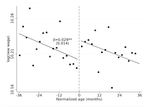

NOTE: figure/graphic rendered as an image from the PDF; its content is not machine-readable text. Caption (if any) follows as the next block.

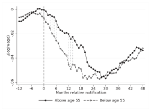

NOTE: figure/graphic rendered as an image from the PDF; its content is not machine-readable text. Caption (if any) follows as the next block.

FIGURE III

Effect of MN on Wages

Panel A shows the log of the wage from the new job after notification by age at notification relative to the age 55 threshold. The estimated jump at the threshold and its standard error are also displayed. The wage refers to full-time equiva- lent monthly wage reported by the employer. The wage from the new job is the first wage that we observe in the Wage Survey within two years after notification. Panel B shows the RD estimates of the difference between the log of the wage in a new job and the wage from the notifying firm observed prior to notification. The hollow circles represent the constant just below the threshold while the filled cir- cles represent the constant plus the discontinuity at age 55. Dashed lines indicate when the discontinuity is significant at the 5% level. In contrast to Panel A, where we only consider the wage in the new job, we include all wage observations after notification in Panel B, including those from the notifying firm and wages obtained from job mobility. The estimates are based on equation (6) controlling for age lin- early interacted with the threshold indicator for individuals aged 52–58 at the time of notification. The regressions also include individual-level baseline covari- ates (earnings in the year prior to notification, gender, immigrant status, tenure, educational attainment fixed effects) and month-by-year fixed effects. Standard errors are clustered by notification event. <sup>∗</sup>*p <* .1, <sup>∗∗</sup>*p <* .05, <sup>∗∗∗</sup>*p <* .01.

wage as a proxy for job quality. Our focus is the wage in the first new job, considering new jobs as those distinct from any job held within 12 months before notification, including the notify- ing one. To avoid selection bias, we follow the literature on the effect of UI on reemployment wages and restrict attention to the first new job within two years after notification ( Card, Chetty, and Weber 2007 ). The two-year time frame avoids selection because the employment effects of MN have subsided after two years (see Online Appendix Figure 3).

We have two distinct approaches to define the first new job. In our first approach we use the Wage Survey. The resulting sam- ple includes 3,932 individuals who are employed by a different firm than the notifying firm. Figure III , Panel A shows that the

Page 24

24 *THE QUARTERLY JOURNAL OF ECONOMICS*

TABLE III EFFECT OF MN ON WAGES AND EE TRANSITIONS

[output not shown]

NOTE: table converted from PDF layout to HTML text; cell boundaries are reconstructed. See PDF if exact alignment matters.

*Notes.* The table shows regression estimates of equation (6) . In column (1) the wage in the new job is defined as the log of the first monthly wage that we observe within two years after notification. The sample contains all individuals who have found a new job according to the Wage Survey. Column (2) restricts the sample by excluding observations where the worker has located another new job prior to the one recorded in the Wage Survey according to the monthly workplace indicators available in the matched employer-employee data. In column (3) we construct the outcome as the difference between the log wage in column (2) and the log wage from the notifying firm. In column (4), we condition on the worker finding the new job directly from employment (EE transition) within six months after notification. In column (5), the outcome is the indicator of making an EE transition within two years after notification. We include a linear age polynomial interacted with the threshold indicator for individuals aged 52–58 at the time of notification as controls. The regressions also include individual-level baseline covariates (earnings in the year prior to notification, gender, immigrant status, tenure, educational attainment fixed effects) and month-by-year fixed effects. Standard errors are clustered by notification event. <sup>∗</sup>*p <* .1, <sup>∗∗</sup>*p <* .05, <sup>∗∗∗</sup>*p <* .01.

MN extension increases wages by 2.9% (standard error 1.4%) on average (see Table III , column (1)).

For our subsequent analysis, it is vital to time job transitions precisely. In the analysis that follows, we estimate wage effects separately for those who make an employer-to-employer transi- tion and for those who experience an unemployment spell in be- tween. Moreover, we connect the wage effects to the job-finding rate and search responses, which requires a consistent sample. These two objectives motivate our second approach to finding the first new job. We use the monthly workplace indicators available in the matched employer-employee data and exclude observations where the worker has located another new job prior to the one recorded in the Wage Survey. The resulting sample measures em- ployment dynamics precisely. The cost is that the number of ob- servations falls by 30%. Despite the reduction in sample size, the wage effects remain statistically significant and of about the same size as in the larger sample ( Table III , columns (2) and (3)). The estimates in column (3), for example, show that longer MN allows

Page 25

*MANDAT ORY NO TICE OF LAYOFF, JOB SEARCH, AND EFFICIENCY* 25

workers to avoid one-third of the wage loss associated with moving to a new job after notification. Whereas workers in the control group experience a wage loss of 9.3% as a result of displacement, longer notification limits the wage loss to 6.1%. Therefore, the ef- fect of being eligible for longer MN is 3.2 percentage points. <sup>20</sup>

The wage effect of MN can stem from three channels: (i) workers targeting higher wages when they search as employed due to longer notice; (ii) a higher likelihood of finding a job while employed; or (iii) workers eligible for longer MN being more se- lective when unemployed, since they receive larger severance. We fully investigate these factors in Sections IV.B and V . At this stage, we offer a simple decomposition to quantify the magnitude of each channel.

The MN extension results in a 4.5% increase in wages for those who make an EE transition within six months after receiv- ing notice ( Table III , column (4)). We focus on a six-month period because longer MN does not affect the likelihood of making an EE transition within this period (see Figure II , Panel B). The share of the main wage effect attributable to a higher selectiveness while searching as employed is obtained by multiplying the column (4) estimate (4.5%) by the EE transition probability for workers el- igible for longer MN ( 0 *.* 566 + 0 *.* 075 = 0 *.* 641 according to column (5)):

Pr ( *E E* ) **E**

ln *w*| *E E*

**equation / math rendering (image)**

NOTE: contains mathematical notation; text above is the PDF text layer and symbols may be mis-extracted. Image shows the original.

= 0 *.* 641 × 4 *.* 5% = 2 *.* 9% *.* (7)

**equation / math rendering (image)**

NOTE: contains mathematical notation; text above is the PDF text layer and symbols may be mis-extracted. Image shows the original.

The decomposition thus suggests that the wage effect when making an EE transition contributes to 91% ( <sup>2</sup> *<sup>.</sup>* <sup>9</sup>

3 *.* 2 <sup>)</sup> <sup>of</sup> <sup>the</sup> <sup>overall</sup> <sup>wage</sup> effect. <sup>21</sup> The other two channels are thus quantitatively unimpor- tant.

Another question is whether the wage effect stems from matches with higher-paying firms or from higher wages condi- tional on a firm match. We examine this issue in Online Appendix

20. The Online Appendix reports additional evidence regarding the MN wage effect. For example, Online Appendix Figure 5(b) shows the result of a permuta- tion test where we vary the age threshold. The one-sided *p* -value associated with the actual threshold at age 55 is .011. Online Appendix Figures 5(c)–(d) show that workers eligible for longer notice avoid large wage losses and have a higher chance of experiencing a large w age increase . Online Appendix Figure 6 pursues the same theme by showing the distributional impact, following Nekoei and Weber (2017) .

21. In the full decomposition, we conclude that 4% of the wage effect is tied to the increase in the probability of making an EE transition, and 5% is due to a wage impact conditional on an EUE transition.

Page 26

26 *THE QUARTERLY JOURNAL OF ECONOMICS*

Table 4 by studying the effect of MN on the characteristics of the new firm, for example, the average w age , firm size , value added, and profits. For most of these dimensions, we do not de- tect statistically significant effects. However, we find that eli- gibility for longer MN increases subsequent firm size by 1.7% ( Online Appendix Figure 7), which indicates that part of the wage effect may be due to securing employment in better firms. In the same vein, workers find new employment in firms paying 1.4% higher wages; although economically important, this estimate is not statistically significant.

We also investigate the effect of MN on other characteristics of the new job (see Online Appendix Table 5). Although we do not have statistical power, all results suggest beneficial effects of MN. In particular, eligibility for longer MN reduces the probability of changing industry or occupation, and increases tenure in the new job. Overall, the nonwage characteristics of the new job are posi- tively but imprecisely affected by MN—a finding consistent with the UI literature (see Nekoei and Weber 2017 ).

Finally, we estimate the wage effects dynamically. Figure III , Panel B depicts the evolution of wages for those just above and below the age 55 threshold, independently of whether they are at the notifying firm, the first subsequent job, or any other job. In general, the wage differences between the two groups have two sources: wage changes associated with a move to another firm and differential rates of remaining at the notifying firm. The pat- terns convey two messages. First, most differences between the two groups manifest during the first year after notification. Sec- ond, wages converge subsequently, with no discernible disparities across the groups after 24 months. These patterns point to the im- portance of finding a new job during the notice period—consistent with the results in Table III —and to stronger incentives for on- ward mobility among workers eligible for short notice, such that they climb the wage ladder faster after obtaining the first job. <sup>22</sup>

4. *MN Effect on Earnings: Total Impact and Decomposition.* Figure IV , Panel A shows RD estimates for earnings in the cal- endar year after notification. Individuals just to the left of the threshold earn 361 kSEK, and individuals just to the right earn

22. Consistent with this finding, Online Appendix Table 3 shows lower wage growth for those above age 55 three years post-notification.

Page 27

*MANDAT ORY NO TICE OF LAYOFF, JOB SEARCH, AND EFFICIENCY* 27

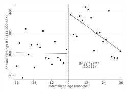

NOTE: figure/graphic rendered as an image from the PDF; its content is not machine-readable text. Caption (if any) follows as the next block.

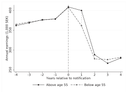

NOTE: figure/graphic rendered as an image from the PDF; its content is not machine-readable text. Caption (if any) follows as the next block.

FIGURE IV

Effect of MN on Annual Earnings

Panel A plots annual earnings in 1,000 SEK in the calendar year after notification against age at notification relative to the age 55 threshold. The estimated jump at the threshold and its standard error are displayed in the figure. In Panel B we plot the RD estimates of earnings effects over time. The hollow circles rep- resent the constant just below the threshold while the filled circles represent the constant plus the discontinuity at age 55. A dashed vertical line indicates when the discontinuity is significant at the 5% level. The regressions in both panels are based on equation (6) including a linear age polynomial interacted with the threshold indicator for individuals aged 52–58 at the time of notification. The regressions also include individual-level baseline covariates (gender, immigrant status, tenure, educational attainment fixed effects) and month-by-year fixed ef- fects. Standard errors are clustered by notification event. <sup>∗</sup>*p <* .1, <sup>∗∗</sup>*p <* .05, <sup>∗∗∗</sup>*p <* .01.

399 kSEK. Extended MN thus increases annual earnings by 11% (38 kSEK).

Figure IV , Panel B illustrates the evolution of annual earnings in different calendar years relative to the notification event for those just above the age 55 threshold (black circled line) and those just below (hollow circled dashed line). It conveys several insights. First, the treatment and control groups are strongly bal- anced during four years before notification. Second, there are no discernible effects of extended MN two years after notification and beyond. A comparison of earnings at event-years 2 and −1 suggests that the earnings losses associated with displacement amount to 26.5% of pre-displacement earnings. These losses are similar in magnitude to those typically documented in the job dis- placement literature (see Jacobson, Lalonde, and Sullivan 1993 ). Third, there is an increase in annual earnings during the year of notification, which is striking given that we expect earnings to fall for notified individuals. This rise is consistent with the existence of severance, as predicted by theory.

Page 28

28 *THE QUARTERLY JOURNAL OF ECONOMICS*

What are the proximate drivers of this overall earnings effect? We decompose earnings according to equation (4) and fo- cus on the first two calendar years after notification because all employment adjustments have subsided by then (see Figure II , Panel B and Online Appendix Figure 3). The earnings effect of longer MN corresponds to 1.60 months of additional pay. Most of this effect can be attributed to the nonemployment effect (59% of the overall effect). Severance contributes to 27% of the earnings difference, and higher wages in the new job contribute to 14%. Online Appendix Table 7 presents additional detail regarding the decomposition.

1 *.* 60 months Earnings effect of MN

≃ 59% ↓ non-emp. dur.

− 0 *.* 4% ↑ new job dur *.*

+ 14% ↑ wage

+ 27% ↑ severance pay

*.* (8)

*IV.B. Separating the Effects of AN and Severance*

We have shown that longer MN helps workers avoid nonemployment and find new jobs that pay higher wages. These reduced-form effects are due to longer AN and larger severance. This section disentangles these two channels, thus isolating the causal impact of each factor on outcomes for displaced workers.

Separating the effect of longer AN from larger severance requires two instruments. In addition to the discontinuity used in Section IV.A , we leverage exogenous variation due to spillovers across individuals within layoff events. Because layoff events en- tail bargaining between the firm and union representatives, we expect layoff packages to be extended to all workers involved in a layoff. In particular, we hypothesize that severance offers are more generous if many coworkers older than 55 are part of the layoff. Online Appendix Figure 14(a) supports this intuition by showing that severance is more generous for workers aged below 55 who are laid off with a larger share of coworkers aged above 55 (and thus eligible for longer MN). Reassuringly, a falsification test suggests that these spillovers only exist for workers below age 55 (see Online Appendix Figure 14(b)).

Building on this finding, we introduce the share of notified (white-collar) coworkers older than 55 as an additional instru- ment. This analysis assumes that the share is quasi-randomly assigned, conditional on observables. Online Appendix Table 9

Page 29

*MANDAT ORY NO TICE OF LAYOFF, JOB SEARCH, AND EFFICIENCY* 29

supports this assumption and shows that pre-notification earnings do not vary with the share of displaced coworkers older than 55. The exclusion restriction prescribes that the share of cowork- ers older than 55 should only affect a notified worker through spillovers in terms of the layoff package.

Table IV shows the instrumental variables estimates, along with the associated first stages and reduced-form estimates. The estimation sample contains white-collar workers aged 52–58 that we use in the previous analyses and all white-collar workers who are notified with them. Adding the latter group increases statis- tical power.

The IV estimates imply that prolonging AN by one month reduces nonemployment exposure by 0.6 months over a two-year horizon and increases wages in the first new job by 1.7%. More- over, an increase in severance of 30 kSEK—around one month of salary—increases nonemployment by 1.5 months but has no sig- nificant impact on wages, neither economically nor statistically.

How does the wage effect compare with prior evidence in the literature? The closest comparison comes from the literature on UI. Our wage estimates are an order of magnitude larger than the estimates of the UI wage effect. A major difference between advance notice and UI is that workers on notice search on the job. Any fundamental differences between search efficiency as employed and unemployed will translate into differences in the wage effect of AN compared with the wage effect of UI. Moreover, workers on notice avoid the negative duration dependence asso- ciated with unemployment. UI induces workers to seek jobs with higher wages, but reduces wages by lengthening unemployment duration. <sup>23</sup> These two counteracting forces lead to an ambiguous net effect of UI on wages in line with the varying results in the empirical literature ( Card, Chetty, and Weber 2007 ; Lalive 2007 ; Sc hmieder, von Wac hter, and Bender 2016 ; Nekoei and Weber 2017 ). The absence of the latter force is an additional reason there is a larger wage effect of AN, relative to UI.

That severance has no wage impact aligns with our finding that the estimated wage effect is mainly associated with EE transitions ( Section IV.A ). The absence of a wage effect of sev- erance also aligns with the findings in Card, Chetty, and Weber

23. See Nekoei and Weber (2017) . For empirical evidence on the effect of unemployment duration on the probability of finding a job, see Kroft, Lange, and Notowidigdo (2013) , Eriksson and Rooth (2014) , Marinescu and Skandalis (2021) .

Page 30

30 *THE QUARTERLY JOURNAL OF ECONOMICS*

TABLE IV

2-IV ESTIMATES: SEPARATING THE EFFECTS OF AN AND SEVERANCE

First-stage estimates Reduced-form (RF) estimates

Notification time Severance Search Months until Nonemployment ln( *w*)

(months) (1,000 SEK) intensity new job (months)

(1) (2) (3) (4) (5) (6)

Panel A

Above age-55 2.593 ∗∗∗ 18.458 ∗∗ −0.222 ∗∗∗ 0.112 −1.176 ∗∗∗ 0.035 ∗∗

(0.193) (7.307) (0.066) (0.319) (0.283) (0.016)

Share coworkers 0.776 30.428 ∗∗∗ −0.064 1.500 ∗∗∗ 1.813 ∗∗∗ −0.002

above 55 (0.678) (11.197) (0.073) (0.378) (0.560) (0.014)

Panel B 2-IV estimates

Notification time −0.087 ∗∗ −0.205 −0.621 ∗∗∗ 0.017 ∗∗

(months) (0.038) (0.241) (0.161) (0.008)

Severance −0.001 0.035 ∗∗∗ 0.051 ∗∗∗ −0.0001

(1,000 SEK) (0.002) (0.013) (0.015) (0.001)

Joint *F-* statistic 90 8 21 26 29 5 Number of clusters 4,285 4,212 4,011 4,060 4,285 2,564 Number of 55,987 49,340 35,515 36,689 56,531 12,590 observations (RF)

*Notes.* The table shows results from our 2-IV strategy, outlined in Section IV.B . Panel A shows first-stage and reduced-form coefficients, and Panel B shows IV estimates. Search

intensity in column (3) is defined as the inverse hyperbolic sine function (arcsinh) of the number of interactions with a PES caseworker up until the worker has found a new job. The

dependent variable in column (4) is the duration of the period between notification and the next job, in column (5) is the duration of the period between the end of the notifying job

and the next job (zero if EE), and in column (6) is the difference in the log wage between the first new job and the notifying job (see Table III , column (2)). The regression specifications

are such that the effect of the *Above age-55* indicator is identified within the sample of white-collar workers aged 52–58, while *Share coworkers above 55* is identified across all

white-collar workers. All regressions include (i) a linear age polynomial interacted with age-brackets fixed effects (the age brackets are six years wide, consistent with the 52–58

bracket), individual-level baseline covariates (earnings in the year prior to notification, gender, immigrant status, tenure, educational attainment fixed effect), and month-by-year

fixed effects. Individual covariates are interacted with a dummy for being close to the threshold (age 52–58). (ii) Firm covariates: average age of workers, average age squared, average

earnings of workers, share female workers, share college educated, and firm size. (iii) Layoff characteristics: size of layoff and flexible controls for average tenure within layoff. (iv)

Two-digit industry FEs. Standard errors are clustered by notification event. The sample comprises all white-collar workers in notification events where a white-collar worker aged

52–58 was notified. The sample drops in column (3), (4), and (6) as we condition on workers having found a new job within two years after notification ( Section IV.A ); the additional drop in column (6) is due to sampling in the Wage Survey ( Section III.B ). ∗*p <* .1, ∗∗*p <* .05, ∗∗∗*p <* .01.

Page 31

*MANDAT ORY NO TICE OF LAYOFF, JOB SEARCH, AND EFFICIENCY* 31

(2007) . However, our estimate of the effect of severance on nonemployment is substantially larger than those in Card, Chetty, and Weber (2007) . They find a 10-day increase in nonemployment af- ter a two-month increase in severance pay. It is difficult to pin- point the exact reasons for the difference in results. An interest- ing difference is that Card, Chetty, and Weber (2007) examine the effect of a mandatory severance program. By contrast, our estimates reflect the causal effect of severance for the subpopula- tion who accept such an offer. According to our theory, this sub- population consists of individuals with a low value of conducting on-the-job search relative to search as nonemployed.

Our wage and nonemployment effects of advance notice are new to the literature. They are substantively large: a one-month increase in the advance notice period leads to a reduction in nonemployment exposure by 0.6 months and an increase in the reemployment wage by 1.7%, after accounting for the effect of severance pay. Again, our theory sheds additional light on the magnitude of these effects. The causal effects of AN are identified in the subpopulation whose value of conducting on-the-job search is particularly high. That the law allows for bilateral agreements that undo the mandate, effectively identifies the population that has most to gain from AN.

Longer AN thus improves the labor market outcomes of notified individuals. One hypothesis is that job search while em- ployed is more effective than job search while unemployed (see Section II ). We now turn to this issue.

V. SEARCH EFFECTIVENESS BY EMPLOYMENT STATUS

This section compares the effectiveness of job search in employment versus unemployment. We first introduce two measures of job search and investigate descriptively how search responds to the news of an upcoming layoff. We use our 2-IV strategy to esti- mate the relative effectiveness of job search as employed versus unemployed. We also probe the robustness of this exercise using two alternative empirical strategies.

We use two complementary sources of information about job search activities. The LFS collects information from individuals regarding their job search activities. It asks about the use of par- ticular searc h c hannels, for example, visiting the PES, scanning job databases, or directly contacting firms. In addition, we lever- age data from the PES, which records a job seeker’s interactions

Page 32

32 *THE QUARTERLY JOURNAL OF ECONOMICS*

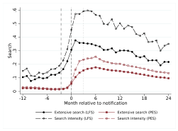

NOTE: figure/graphic rendered as an image from the PDF; its content is not machine-readable text. Caption (if any) follows as the next block.

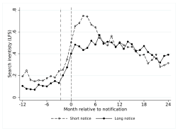

NOTE: figure/graphic rendered as an image from the PDF; its content is not machine-readable text. Caption (if any) follows as the next block.

FIGURE V

Search by Month Relative to Notification

with the assigned caseworker. The LFS offers detailed insights into job search patterns, while the PES data provide comprehen- sive coverage of the population and relies on third-party reports.

We start by introducing these data descriptively and comparatively in an investigation of how job search responds to notifica- tion. Using the LFS, Figure V , Panel A shows that around 10% of employed individuals report searching actively for a job (line labeled “Extensive search (LFS)”). Search effort increases after the initial layoff report and surges even further at the time of the individual notification to a level of around 30%. Search then

Page 33

*MANDAT ORY NO TICE OF LAYOFF, JOB SEARCH, AND EFFICIENCY* 33

remains persistently high. <sup>24</sup> All other series in Figure V , Panel A show that notification yields additional search activity. However, the effect on the PES measure is only visible after individual noti- fication and not after the initial layoff report, and the magnitude of the response is muted relative to the more comprehensive LFS measure. In part, this might be due to the fact that registering with the PES is a precondition for collecting UI.

We turn to the main goal of this section: estimating the relative effectiveness of search. For this purpose, exogenous variation in AN provides an ideal conceptual experiment. Over a fixed time frame, the alternative to receiving an additional month of search time during the notice period (i.e., while still being employed) is one month of search as unemployed. We therefore use our 2-IV approach from Section IV.B to identify the effect of AN separately from severance. Table IV shows that the number of contacts with the PES caseworker is reduced by 8.7% due to longer AN. <sup>25</sup> The estimated reduction in the duration until a new job ( −0 *.* 205 on a base of 8.28 months) suggests a slight (and nonsignificant) in- crease in the job-finding rate by 2.5%. <sup>26</sup> The striking fact is that the job-finding rate is barely affected despite the fact that longer notice reduces search and increases wages. This finding implies

24. The persistent increase in search intensity is most likely tied to the negative earnings impact of displacement (e.g., Jacobson, Lalonde, and Sullivan 1993 ). The literature shows that displacement causes a reduction in future employment prospects (e.g., Cederlöf 2024 ) and wages (e.g., Lachowska, Mas, and Woodbury 2020 ; see also Table III , column (2)). 25. A caveat of the 2-IV design is that it uses the less granular PES measure of search because we lack statistical power using the LFS measure.

26. Online Appendix Figure 16 shows direct estimates of the job-finding rate. There is little variation in the effect of MN on job finding over all time horizons after notice. It also shows how MN affects search over time.

Page 34

34 *THE QUARTERLY JOURNAL OF ECONOMICS*

that it is more effective to search from employment compared to searching from unemployment.

Conceptually, job-search strategies vary based on the individual’s diligence in seeking a job (search intensity) and the qual- ity of the jobs they seek (i.e., the target or reservation wage). However, the small literature on the topic (see Blau and Robins 1990 ; Faberman et al. 2022 ), focuses solely on the effectiveness of search intensity. It studies the relationship between the job- finding rate and search activity—which we refer to as the re- turn to search—and how this relationship varies by employment status—the relative return to employed search. Our estimates from the 2-IV design suggest a relative return to employed search of <sup>1</sup><sup>+</sup><sup>0</sup> *<sup>.</sup>* <sup>025</sup>

To probe the robustness of this result, we begin by regressing the hazard rate on reported search effort in the LFS separately for the employed and the nonemployed, adjusted for observed differ- ences across the two groups ( Table V , columns (1) and (3)). While straightforward, this OLS approach suffers from the problem that search effort is endogenously chosen. Fortunately, the LFS is a rotating panel where each individual is surveyed in eight consec- utive quarters, so we can thus estimate the relationship between the job-finding rate and search in a sample that is restricted to individuals who experience both employment and unemployment during the panel. This ensures that the composition of the two groups is held constant. In addition, we include individual fixed effects that are allowed to vary by employment status. <sup>27</sup> The re- turn to search from employment is uniformly higher than the re- turn to search from unemployment ( Table V ). Our preferred spec- ification, presented in column (4), holds composition constant and suggests that the return to searching from employment is 25% higher than searching from unemployment.

A concern with the estimates in Table V is that they could be confounded by variation in the target w age . To tackle this is- sue, we use two exogenous shifters of search among unemployed and employed workers where we a priori expect wage effects to

27. The addition of these fixed effects does not significantly alter the estimates. The key point is that the sample composition is held constant.

Page 35

*MANDAT ORY NO TICE OF LAYOFF, JOB SEARCH, AND EFFICIENCY* 35

TABLE V JOB SEARCH AND THE HAZARD RATE FOR THE EMPLOYED AND UNEMPLOYED

[output not shown]

NOTE: table converted from PDF layout to HTML text; cell boundaries are reconstructed. See PDF if exact alignment matters.

*Notes.* The table uses the Labor Force Survey (LFS) and reports the results of OLS regressions where the outcome is a binary indicator of finding a new job in the next quarter. The search measure in columns (1) and (2) is an indicator for those self-reporting the use of any of eight searc h c hannels (visiting the PES, using a PES job coac h, searc hing jobs databases, searc hing via recruitment firms, searching by directly approaching firms, applying to posted ads, reading ads, or asking friends for job tips). The mean is 0.200 for the unem- ployed versus 0.070 for the employed. The search measure in columns (3) and (4) is the inverse hyperbolic sine of the number of search channels used. All regressions control for gender-by-education fixed effects interacted with a third-order age polynomial as well as calendar month and year fixed effects. All controls, including individual fixed effects, are interacted with employment status. Significance asterisks for the relative search effectiveness estimates refer to the null of the ratio being equal to one. Standard errors are clustered at an individual level. <sup>∗</sup>*p <* .1, <sup>∗∗</sup>*p <* .05, <sup>∗∗∗</sup>*p <* .01.

be small or nonexistent. For the unemployed, we leverage that UI benefits are capped in a regression-kink design ( Kolsrud et al. 2018 ). Under the exclusion restriction that target wages are un- affected by UI benefits, this provides an estimate of the causal relationship between the hazard and search activity. For the em- ployed, we leverage variation in MN driven by the tenure and age rules among notified individuals. In particular, we use variation during the MN period. We focus on job search during the period from the initial layoff report (around −2 ) to +2 for those who were notified at *t* = 0 , and were eligible for two to six months of MN. This population is much broader than the one considered in the main analysis. As a result, their observed characteristics are com- parable to the average notified individual described in Table I , column (1).

Page 36

36 *THE QUARTERLY JOURNAL OF ECONOMICS*

TABLE VI THE RETURN TO SEARCH FOR EMPLOYED AND UNEMPLOYED

[output not shown]

NOTE: table converted from PDF layout to HTML text; cell boundaries are reconstructed. See PDF if exact alignment matters.

*Notes.* Each coefficient derives from separate regressions where the outcomes are reported in each row. Panel A shows the reduced-form effects exploiting exogenous variation in search for employed and unem- ployed, respectively. The independent variable in column (1) is de jure notice time (in months) while column (2) exploits the cap in the UI benefit schedule in an RKD design. Panel B shows the effect of search on the hazard to a new job in the next month using a two-sample IV-strategy. For column (1), the sample includes notified workers between 2005–2016 with 2–6 months de jure notice time, while column (2) includes all un- employed workers eligible for UI between 2005–2015. The outcomes in column (1) are measured between the initial layoff report and two months after individual notice, that is, in close vicinity of individual notification (on average a four-month period). Regressions in column (1) control for individual-level baseline covariates (earnings in the year prior to notification, gender, immigrant status, age, tenure, and educational attainment fixed effects), and month-by-year fixed effects. Column (3) shows the ratio of the estimates in Panel B where standard errors are calculated using the delta method. Standard errors in columns (1) and (2) are clustered at the individual level. <sup>∗</sup>*p <* .1, <sup>∗∗</sup>*p <* .05, <sup>∗∗∗</sup>*p <* .01.

Table VI presents the results. <sup>28</sup> Because the LFS is available for a small subsample, we increase the statistical power by imple- menting a two-sample IV approach (see Inoue and Solon 2010 ), where we estimate the reduced-form impact on the hazard in the population. For the employed, Panel A, column (1) shows that be- ing eligible for longer MN lowers search as well as the hazard to a new job. For the unemployed, column (2) shows that a lower UI replacement rate increases search and the hazard to a new job.

28. Online Appendix Figure 17 illustrates the reduced-form estimates for the RKD design. Miika Päällysaho kindly provided the code implementing the RKD design.

Page 37

*MANDAT ORY NO TICE OF LAYOFF, JOB SEARCH, AND EFFICIENCY* 37

The estimates in column (2) imply that the elasticity of search with respect to the UI replacement rate is 0.4. <sup>29</sup> The impact on the hazard is consistent with Kolsrud et al. (2018) . According to Panel A, the effects of these shifters on the wage in the new job are not significant, supporting the exclusion restriction. The IV esti- mates show that the impact of search activity on the job-finding rate as employed (unemployed) amounts to 20.7 (16.1) percent- age points. These causal estimates are new to the literature. The return to searching from employment is higher than the return to searching from unemployment with an implied relative return of 1.285. We obtain the same conclusion if we replace the search indicator with a measure of search intensity. The relative return to employed search in this case is 1.190. Both estimates are sta- tistically significant.

Figure VI summarizes the results across the three designs. Despite potential differences in the complier populations across the three designs, the results provide a consistent message: the job-finding rate per unit of search for the employed relative to the unemployed ranges from 1.123 to 1.285. These estimates com- plement the survey evidence in Faberman et al. (2022) , who find that the job offer arrival rate per unit of search for the employed relative to the unemployed is 3. While qualitatively aligned, our estimates are an order of magnitude lower. One reason for this discrepancy is that our estimates are not confounded by compo- sitional differences between the employed and unemployed. To conclude, the beneficial effects of MN on wages and nonemploy- ment are at least partly driven by the return to job search being higher in employment than in unemployment.

VI. COSTS OF MANDATORY NOTICE

While the focus of Section IV is on the benefits of MN, this section considers the costs of the mandate. Section VI.A exploits variation in notification times across firms to provide an estimate of the average productivity loss of notice—*α* in the framework of Section II . In Section VI.B we estimate the production loss

29. We obtain the elasticity as follows. We divide the change in slopes for search (0.222 from Table VI , column (2)) with the level at the kink (0.65 as shown in Online Appendix Figure 17b). We divide this estimate by the change in slopes of the replacement rate ( −0 *.* 64 ) divided by the replacement rate at the kink (0.76).

Page 38

38 *THE QUARTERLY JOURNAL OF ECONOMICS*

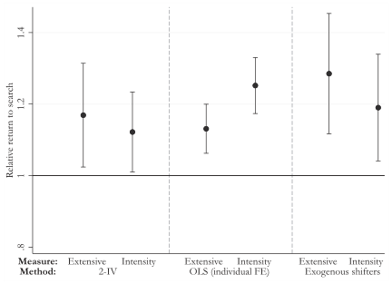

NOTE: figure/graphic rendered as an image from the PDF; its content is not machine-readable text. Caption (if any) follows as the next block.

FIGURE VI

Relative Return to Job Search for Employed versus Unemployed

The figure summarizes our estimates of the relative return to job search among employed versus unemployed using three empirical designs and two measures of search activities: the extensive margin and search intensity (arcsinh). The left- most two dots correspond to the estimated return using the 2-IV strategy as in Table IV , column (3). These are lower-bound estimates of the return to search given the higher target w age . The next two dots show the relative returns obtained using the OLS strategy presented in Table V , columns (2) and (4). The final two dots use the exogenous shifters as in Table VI , column (3). Each dot is surrounded by 95% confidence intervals.

associated with the delay of separation due to MN. <sup>30</sup> The analysis of the costs of MN requires stronger assumptions than our previous RD analysis, since we generally cannot rely on the age threshold for identification.

*VI.A. MN Effect on Productivity*

The productivity of notified workers may decline as they reduce their work effort and increase their search for alternative employment. The goal of this section is to estimate the magnitude of the productivity loss due to notification, that is, *α* as defined in Section II.B . We consider firms that give notice to some employ- ees and we leverage variation across firms in how long notified

30. Online Appendix II.D provides evidence that cash-constrained firms do not pay severance, indicating that some firms provide inefficient AN.

Page 39

*MANDAT ORY NO TICE OF LAYOFF, JOB SEARCH, AND EFFICIENCY* 39

workers stay at the firm. <sup>31</sup> A summary of the analysis is provided here, while additional details of the analysis and the construction of the firm sample can be found in Online Appendix D.

Following Section II , a worker’s productivity falls by a factor *α* once notified. The production at firm *i* at time *t* is therefore *Y it* = *A it* ( 1 −*αχit* ) *L it* , where *χit* is the share of labor (months worked) provided by notified workers, *A* denotes total factor productivity (TFP), and *L* is the number of employees. The change over time in the log of average worker productivity at the firm is ln *y i* = ln *A i* + ln ( 1 −*αχit* ) , where *y i* = *<sup>Y</sup> <sup>i</sup>*

*L i* <sup>.</sup> The share of labor provided by notified workers is *χi* = *s i* × *m i* , where *s i* denotes the share of notified employees and *m i* the average months worked among workers on notice relative to the overall average. Both *s i* and *m i* are likely endogenous to *y i* , *s i* is directly related to the size of the TFP shock, and *m i* partly reflects the choices of workers and firms.

As a starting point, we use OLS to estimate *α*. We address the issue of endogeneity of *s i* and *m i* by controlling for inter alia fixed effects for the percentiles of the *s* and *m* distributions, re- spectively, and identify *α* from their interaction. We thus compare firms hit by equally sized shocks ( *s* ), and ask whether the impact of this shock depends on how many months notified workers stay at the firm ( *m* ). The resulting estimate of *α* may be biased down- ward as firms with a larger productivity drop due to notice—high *α*—shorten the AN period by paying severance to arrive at a lower *m* .

We use an IV approach to deal with this endogeneity problem. We construct an instrument for *m* based on two institutional features of our setting. First, we exploit variation in MN that is due to age and tenure (see Section III.A ). Second, we use the LIFO rules that determine how redundancies should be made (see Section III.A for details). The instrument—denoted *m i* —takes the number of notified workers in each occupation as given and cal- culates the MN period for workers who would have been notified according to the LIFO rules. This approach addresses endogene- ity concerns regarding selection into displacement and that the actual time spent at the notifying firm may be driven by unob- served heterogeneity.

31. This period is distinct from both MN and AN because it corresponds to the time a notified worker stays with the notifying firm. It is causally affected by MN as shown in Section IV.A .

Page 40

40 *THE QUARTERLY JOURNAL OF ECONOMICS*

The IV approach compares firms that are exposed to equally sized shocks and quantifies the productivity drops due to longer notice induced by MN. Concretely, we implement the following 2SLS approach

**equation / math rendering (image)**

NOTE: contains mathematical notation; text above is the PDF text layer and symbols may be mis-extracted. Image shows the original.

*s i* × ( *m i* ) <sup>2</sup>

+ *δt* + *δj*(*i* ) + *f χ*(*s i* )

**equation / math rendering (image)**

NOTE: contains mathematical notation; text above is the PDF text layer and symbols may be mis-extracted. Image shows the original.

+ *g χ*( *m i* ) + *hX i* + *ϵi* (9)

ln *y i* = *βχi* + *d t* + *d j*(*i* ) + *f y* (*s i* ) + *g y* ( *m i* ) + *ηX i* + *ε i ,* (10)

where *i* denotes a notification event and *m i* the instrument, *δt* ( *d t* ) and *δj*(*i* ) ( *d j*(*i* ) ) are notification time and industry fixed effects, re- spectively. *X i* denotes mean age and tenure of workers at the firm, which we also interact with *s* . <sup>32</sup> Equation (9) is the first stage, and equation (10) the structural equation in our IV setting. The IV estimate of *β* is identified by the interaction terms *s i* × *m i* and *s i* × *m i*

2 . The second-order interaction term improves the fit of the first-stage regression considerably. <sup>33</sup>

Throughout the IV analysis, we hold *s* constant since *m i* increases with *s* because of the LIFO rule that prioritizes low- tenure workers (low-notice workers) over high-tenure workers in a layoff event. We also control flexibly for *m i* because the instru- ment depends on the workforce composition, which in turn may depend on changes in firm productivity. For instance, firms with sluggish productivity may have lower hiring rates, leading to a workforce skewed toward high-tenure and older workers (and thus higher *m i* ). In addition, the workforce composition may di- rectly affect productivity, beyond the effects of average age and tenure, which are accounted for in the regression. <sup>34</sup>

The identification assumption is that a layoff shock of given size would have affected firm productivity in the same way with- out the MN rules. Alternatively, productivity in firms with differ- ent exposure to MN would have evolved in the same way without

32. The interaction terms alleviate the risk that the effect of the shock on productivity varies with average age and tenure for reasons not related to AN.

33. As shown by Table VII , the value of the first-stage *F* -statistic is 222 compared to the first-stage *F* of 79.4, obtained with a linear interaction term. We illustrate the first-stage relationship in Online Appendix Figure 25.

34. Another reason for controlling for *m i* is that firms may postpone layoffs in response to MN. When the firm keeps the worker longer than is optimal—because of its inability to predict the productivity decline or because MN creates incentives to dela y la yoffs (see Section VI.B )—a larger portion of the work spell has lower productivity. This, however, is not due to the behavior of workers.

Page 41

*MANDAT ORY NO TICE OF LAYOFF, JOB SEARCH, AND EFFICIENCY* 41

TABLE VII THE PRODUCTIVITY LOSS OF NOTICE

[output not shown]

NOTE: table converted from PDF layout to HTML text; cell boundaries are reconstructed. See PDF if exact alignment matters.

*Notes.* The table shows estimates of productivity losses from having workers on notice, that is, *α* of Section VI.A . For the dependent variables we use *y* = revenue per worker. Columns (1) and (3) present OLS estimates, while columns (2) and (4) present IV es- timates. The first stages regress *χ* on *s* × *m i* and *s* × ( *m i* ) <sup>2</sup> , where *s i* denotes the share of notified employees and *m i* denotes the de jure instrument. We include mean age and mean tenure at the firm as controls, as well as the interactions between these two vari- ables and *s* . We also include fixed effects for each percentile rank of the *s* -distribution (share notified) as well as *s* entered linearly. Along the same lines, we include fixed effects for each percentile rank of the *m* ( *m i* )-distribution and *m* ( *m i* ) entered linearly. Finally, all regressions include calendar year and month fixed effects. Online Appendix D describes the firm analysis in greater detail. The mean and variance of *χ* are 0.069 and 0.103. Standard errors are clustered on firms. <sup>∗</sup>*p <* .1, <sup>∗∗</sup>*p <* .05, <sup>∗∗∗</sup>*p <* .01.

the layoff shock. In addition to the relevance condition, our IV analysis thus requires that

*E*( *ε i* | *s i* × *m i , s i , m i ,* ) = *E*( *ε i* | *s i , m i ,* ) *,*

**equation / math rendering (image)**

NOTE: contains mathematical notation; text above is the PDF text layer and symbols may be mis-extracted. Image shows the original.

where denotes the vector of other variables held constant in equation (10) . The fact that the pre-notification evolution of the marginal revenue product is unrelated to subsequent average no- tice duration across firms supports this assumption (see the rows pertaining to outcomes *t* −1 and *t* −2 in Table VII ).

The first rows of Table VII contain our main results. The unit of observation is a layoff event, defined as a calendar year when

Page 42

42 *THE QUARTERLY JOURNAL OF ECONOMICS*

the firm notifies some employees of a layoff. To avoid notification times extending across calendar years, we restrict attention to layoff events that are preceded by at least two years without no- tifications. <sup>35</sup>

The dependent variable in columns (1) and (2) is the change in log annual revenue per worker between the event year and one year prior to the event. The dependent variable in columns (3) and (4) is the log of annual revenue per worker during the event year relative to average log revenue per worker during the pre- ceding three years. The estimates of the productivity loss, *α*, are calculated as ˆ *α* = <sup>1</sup> <sup>−</sup><sup>exp</sup> <sup>(</sup> <sup>ˆ</sup> *β* ¯*χ*) ¯*χ* . The OLS estimates in columns (1) and (3) deliver estimates of around 0.28, whereas the IV estimates in columns (2) and (4) suggest that ˆ *α* ≃ 0 *.* 46 *.* The average of the estimates in Table VII is 0.37, which suggests that a worker’s pro- ductivity falls by around one-third during the notification period.

*VI.B. The Production Loss Due to Delay in Separations*

Section II points out that the efficiency loss of MN comes from delay—that is, some matches are destroyed later than would be optimal from a production efficiency point of view. Here, we ad- dress two questions. First, to what extent does an extension of MN cause a delay in separation? Second, what is the magnitude of the production loss of such delay?

Before turning to these questions, we briefly discuss the determinants of delay. As emphasized in Section II , a firm that no- tifies the worker when the match is still viable incurs the pro- duction cost, *αy* . The firm trades off this cost against the cost of delaying separation. In partial equilibrium, the cost equals: *w* −( 1 −*z* ) ( 1 −*α*) *y* . Thus, the likelihood of delay increases with *α*. Online Appendix VI.B extends this result to a continuous time setting. In general, MN affects AN by advancing the timing of no- tification and postponing the timing of layoff. Indeed, with a lin- ear productivity decline, delay is proportional to *α*. <sup>36</sup> This result is derived in a setting where the firm can time individual layoffs to MN. In practice, however, the layoffs in our setting are collec- tive, typically involving workers with differential eligibility for

35. A firm may appear multiple times if it has multiple events. We cluster standard errors on firms to allow for correlation across events within a firm.

36. In general, an increase in *α* makes the timing of layoff more responsive to MN than the timing of notification. We also show that there is no delay in the extreme case where *α* = 0 .

Page 43

*MANDAT ORY NO TICE OF LAYOFF, JOB SEARCH, AND EFFICIENCY* 43

MN. If the firm wants to lay off some of its workers at the same time, it would have to notify workers eligible for long MN ear- lier than other workers. However, because LIFO prescribes that workers are laid off in inverse order of seniority and because se- niority and MN are highly correlated, it will be hard for the firm to notify long-MN workers before those with short MN. Empiri- cally, we find a negligible adjustment of the timing of notification in response to extended MN (see Online Appendix Table 1), sug- gesting that we can approximate the duration of delay using the increase in the duration at the notifying firm (1.32 according to Table II ).

Next we examine the cost of delay. Intuitively, this cost is approximated by the worker’s expected earnings in an alterna- tive job, had the layoff not been delayed. To measure this coun- terfactual earnings stream for marginal employees—those most likely to get delayed—we conduct the following empirical exer- cise. We focus on establishments involved in two consecutive lay- off events that are three to six months apart. Three months is a natural lower limit since workers notified within this period are considered part of the same layoff event (see Section III ). We sort workers by seniority within layoff event. <sup>37</sup> When workers are laid off in inverse order of seniority according to the LIFO rule, the least senior worker in the second event could have been laid off as the most senior worker in the first event had the first event been marginally larger. To measure counterfactual earnings, we thus cumulate earnings from the initial layoff report (of the first event) for all workers involved in these two events. We relate cu- mulative earnings to annual earnings prior to the layoff to get a convenient metric. This measure overestimates the production loss of delay to the extent that the productivity in the notifying firm ( (1 −*z* )(1 −*α*) *y* ) exceeds the value of home production ( *b*).

Relative to prior earnings, the least senior worker in the second layoff lost 1.21 months of earnings in comparison to the marginal worker in the first layoff ( Online Appendix Figure 18). Taking into consideration that the two layoff events are on aver- age 4.14 months apart, the earnings loss corresponds to 0.29 of monthly earnings per month of delay. We thus conclude that the cost of the delay induced by the MN extension is equivalent to 0.38 ( 0 *.* 29 × 1 *.* 32 = 0 *.* 38 ) months of earnings.

37. This analysis includes all workers—both blue-collar and white-collar, with no age restrictions—in contrast to our RD approach.

Page 44

44 *THE QUARTERLY JOURNAL OF ECONOMICS*

VII. PRODUCTION EFFICIENCY

This section investigates the impact of MN on production efficiency. We calculate the net effect of MN on total production by inserting estimates from Sections IV and VI into equation (5) . The estimates yield total production gains of crossing the age 55 threshold of 1 *.* 60 × (1 −0 *.* 274) = 1 *.* 16 of the average monthly wage per notified worker (the standard error is 0.26); we deduct the severance effect of MN—27.4% of the total earnings effect— since severance is a transfer from the firm to the worker.

The production losses due to MN have two components. We first combine the estimated production loss factor, *α*, from Section VI.A (we use *α* = 0 *.* 37 , that is, the average of the estimates in Table VII ) with the additional number of months a notified worker stays in the notifying firm (1.32 according to Table II ) to obtain a production loss due to the productivity drop among no- tified workers that equals 0.49 (std. err. 0.21). We thus find a net production gain of notice that corresponds to 0.67 of a monthly wage (std. err. 0.33). The second component of the production losses come from delay. According to Section VI.B , the production loss due to delay is 0.38 of a monthly w age . Combining the vari- ous pieces together in equation (11) , we conclude that extending MN yields a net production gain of 0.29 of a monthly w age . Al- though positive, this estimate is not statistically significant, with a standard error of 0.35.

1 *.* 60 × (1 −0 *.* 274) Earnings gain

− 0 *.* 37 Productivity drop

× 1 *.* 32 Addtional tenure Net Production Gain of Notice = 0 *.* 67

− 0 *.* 29 Delay Cost

× 1 *.* 32 Delay Production Loss of Delay = 0 *.* 38

≃ 0 *.* 29 Monthly wage Net Production Effect

*.* (11)

To better understand the economic significance of the production gain, we conduct two back-of-the envelope calculations. First, we consider a reform that applies the MN extension to all sepa- rations, while assuming that the treatment effect can be general- ized to the overall population. Such a reform would increase ag- gregate labor income by 0 *.* 29 × 0 *.* 87% = 0 *.* 25% . Here, 0 *.* 87% cor- responds to the monthly separation rate for Sweden, as estimated by Hobijn and Sahin (2009) . Second, we compare the production gain with the duration of the MN extension (six months). This

Page 45

*MANDAT ORY NO TICE OF LAYOFF, JOB SEARCH, AND EFFICIENCY* 45

suggests that 5% of the MN extension is converted into increased production per eligible laid-off worker. Given that not all workers above 55 are eligible for the MN extension, this is a lower-bound estimate.

There are two concerns about the external validity of the estimated net effect on production. First, it is key in our context that it is possible to replace AN with severance. Because we observe a significant effect of MN on severance, the mandate was not effi- cient in some cases. Second, the MN extension applies to a subset of the population—high-age, long-tenured workers—whose gains from advance notice may be particularly large.

Let us turn to the fiscal implications of the MN extension, which we have ignored thus far. To estimate the fiscal externality of MN, we first note that the average sum of the tax rate on la- bor income and the payroll tax amounts to around 60%, *τ* ≃ 0 *.* 6 . Coupled with the above estimate of the net production gain, MN thus raises tax revenue by 17% of a monthly w age . In addition, MN reduces the duration of unemployment, creating another pos- itive fiscal externality. With an average replacement rate of 50%, *ρ* ≃ 0 *.* 5 , and our estimate of the unemployment duration effect of MN from Table II ( −0 *.* 472 ), we find a fiscal externality corre- sponding to 24% of the average monthly w age . <sup>38</sup> Putting these two externalities together, the total fiscal externality, resulting from the extension of MN at age 55, corresponds to 0.41 of a monthly w age , with a standard error of 0.24.

*τ* × 0 *.* 29 Production gain ↑ Taxes 0.17

−*ρ* × −0 *.* 47 Unemp. dur. ↓ UI benefit 0.24

≃ 0 *.* 41 Monthly wage fisc. externality

*.* (12)

These calculations are indicative but should be taken with a grain of salt. In addition to the external validity concerns, we should also note that we have ignored the potential effect that MN might have on hiring. Hiring will be adversely affected if firms cannot shift the average cost of the policy onto workers in the form of a reduction in wages.

38. A 50% replacement rate aligns with reality, given the low earnings cap in the public UI system during the period and the high-income group considered.

Page 46

46 *THE QUARTERLY JOURNAL OF ECONOMICS*

VIII. CONCLUDING REMARKS

MN policies require employers to inform employees in advance of layoff. Despite the widespread prevalence of these poli- cies, the literature on MN is limited. We analyze the positive and normative aspects of the requirement to inform workers in ad- vance of layoff.

One main lesson of our analysis is that some MN is generally optimal. Inducing firms to provide AN encourages workers to search while still employed, helping them to find higher-quality jobs on reemployment. There is more uncertainty regarding the length of MN, however. A concern—that further research should engage with—is that MN puts financial pressure on firms, partic- ularly when they are already facing difficulties. Another concern is general equilibrium effects of MN on hiring. Such effects are relevant if firms cannot reduce wages to shift the cost of the pol- icy onto workers. While we have offered a framework that sheds light on the trade-off involved in determining the optimal dura- tion of the mandate, we have left other questions regarding the detailed design of the policy for future work.

We have provided novel empirical analyses on several fronts. We believe that two empirical findings are particularly funda- mental. First, we have shown that severance is used to sidestep the law. Lazear (1990) points out that private contracts undo poli- cies, limiting their effect on the real economy. But private con- tracts only undo policies when they are inefficient. Thus studying why and how labor laws are circumvented using private contracts teaches us about the efficiency of the public mandate in question. When the law is not undone using private contracts, this may in- deed signal that it improves allocations and efficiency.

Second, we find that AN replaces job search while unemployed with more effective search while employed. Despite re- duced search activity and higher reemployment wages, extend- ing AN does not delay job finding. Employed job search offers a higher return to search—in the sense of a higher job-finding rate—and workers can target higher-quality jobs without a de- cline in job-finding rates. We have offered new evidence on the return to search activity across employment states and find that it is indeed higher during employment. However, we cannot gauge the extent to which targeting a better job is easier for an employed worker. We hope that further research will shed light on this key issue.

Page 47

*MANDAT ORY NO TICE OF LAYOFF, JOB SEARCH, AND EFFICIENCY* 47

At several stages of our analysis, we pointed to the similarities and differences between MN and UI. An additional point is that MN has the advantage of forcing firms to internalize part of the layoff cost in a non–experience-rated UI system. We think further analysis of the advantages or disadvantages of MN and UI, and the potential interactions between these two systems, is an interesting avenue for further research.

INSTITUTE FOR EVALUATION OF LABOUR MARKET AND EDUC A TION POLICY, SWEDEN UPPSALA UNIVERSITY, SWEDEN INSTITUTE FOR INTERNATIONAL ECONOMIC STUDIES (IIES), STOCKHOLM UNIVERSITY, SWEDEN STOCKHOLM UNIVERSITY, SWEDEN

SUPPLEMENT ARY MA TERIAL

An Online Appendix for this article can be found at *The Quarterly Journal of Economics* online.

DA T A AVAILABILITY

The data underlying this article are available in the Harvard Dataverse , https://doi.org/10.7910/D VN/JC9K31 ( Cederlöf et al. 2024 ).

REFERENCES

Addison, John T. , and McKinley L. Blackburn, “Policy Watch: The Worker Adjust-

ment and Retraining Notification Act,” *Journal of Economic Perspectives* , 8 (1994), 181–190. https://doi.org/10.1257/jep.8.1.181 . Alfitian, Jakob , and Timo Vogelsang, “The Hidden Costs of Dismissal: Behavioral

Consequences of Impending Termination,” SSRN, 2022. https://doi.org/10.2 139/ssrn.4292097 . Baily, Martin Neil , “Some Aspects of Optimal Unemployment Insurance,” *Jour-*

*nal of Public Economics* , 10 (1978), 379–402. https://doi.org/10.1016/0047-2 727(78)90053-1 . Blanchard, Olivier J. , and Jean Tirole, “The Joint Design of Unemployment Insur-

ance and Employment Protection: A First Pass,” *Journal of the European Economic Association* , 6 (2008), 45–77. https://doi.org/10.1162/JEEA.2008.6.1.45 . Blau, David M. , and Philip K. Robins, “Job Search Outcomes for the Employed

and Unemployed,” *Journal of Political Economy* , 98 (1990), 637–655. https: //doi.org/10.1086/261698 . Burgess, Paul L. , and Stuart A. Low, “Preunemployment Job Search and Advance

Job Loss Notice,” *Journal of Labor Economics* , 10 (1992), 258–287. https://do i.org/10.1086/298287 . Calonico, Sebastian , Matias D. Cattaneo, and Rocio Titiunik, “Robust Nonpara-

metric Confidence Intervals for Regression-Discontinuity Designs,” *Econometrica* , 82 (2014), 2295–2326. https://doi.org/10.3982/ECTA11757 .

Page 48

48 *THE QUARTERLY JOURNAL OF ECONOMICS*

Card, David , Raj Chetty, and Andrea Weber, “Cash-on-Hand and Competing Mod-

els of Intertemporal Behavior: New Evidence from the Labor Market,” *Quarterly Journal of Economics* , 122 (2007), 1511–1560. https://doi.org/10.1162/qj ec.2007.122.4.1511 . Cederlöf, Jonas , “Reconsidering the Cost of Job Loss: Evidence from Redundancies

and Mass Layoffs,” IFAU Working Paper 2024:2(2024). Cederlöf, Jonas , Peter Fredriksson, Arash Nekoei, and David Seim, “Replication

Data for: ‘Mandatory Notice of Layoff, Job Search, and Efficiency’,” (2024), Harvard Dataverse. https://doi.org/10.7910/DVN/JC9K31 . Chetty, Raj , “A General Formula for the Optimal Level of Social Insurance,” *Jour-*

*nal of Public Economics* , 90 (2006), 1879–1901. https://doi.org/10.1016/j.jpub eco.2006.01.004 . Eriksson, Stefan , and Dan-Olof Rooth, “Do Employers Use Unemployment as a

Sorting Criterion When Hiring? Evidence from a Field Experiment,” *American Economic Review* , 104 (2014), 1014–1039. https://doi.org/10.1257/aer.10 4.3.1014 . Faberman, R. Jason , Andreas I. Mueller, Ay ¸s egül ¸S ahin, and Giorgio Topa, “Job

Search Behavior among the Employed and Non-Employed,” *Econometrica* , 90 (2022), 1743–1779. https://doi.org/10.3982/ECTA18582 . Hobijn, Bart , and Ay ¸s egül ¸S ahin, “Job-Finding and Separation Rates in the

OECD,” *Economics Letters* , 104 (2009), 107–111. https://doi.org/10.1016/j.ec onlet.2009.04.013 . Ifergane, Tomer , “Time to Say Goodbye: The Macroeconomic Implications of Ter-

mination Notice,” London School of Economics Working Paper, 2022. Inoue, Atsushi , and Gary Solon, “Two-Sample Instrumental Variables Estima-

tors,” *Review of Economics and Statistics* , 92 (2010), 557–561. https://doi.org/ 10.1162/REST _ a _ 00011 . Jacobson, Louis S. , Robert J. Lalonde, and Daniel G. Sullivan, “Earnings Losses

of Displaced Workers,” *American Economic Review* , 83 (1993), 685–709. Jones, Stephen R. G. , and Peter Kuhn, “Mandatory Notice and Unemployment,”

*Journal of Labor Economics* , 13 (1995), 599–622. https://doi.org/10.1086/2983 86 . Kolsrud, Jonas , Camille Landais, Peter Nilsson, and Johannes Spinnewijn, “The

Optimal Timing of Unemployment Benefits: Theory and Evidence from Sweden,” *American Economic Review* , 108 (2018), 985–1033. https://doi.org/10.1 257/aer.20160816 . Kroft, Kory , Fabian Lange, and Matthew J. Notowidigdo, “Duration Dependence

and Labor Market Conditions: Evidence from a Field Experiment,” *Quarterly Journal of Economics* , 128 (2013), 1123–1167. https://doi.org/10.1093/qje/qjt0 15 . Krueger, Alan B. , and Bruce D. Meyer, “The Labor Supply Effects of Social

Insurance,” in *Handbook of Public Economics, vol. 4* , Alan Auerbach and Martin Feldstein, eds. (Amsterdam: North-Holland, 2002), 2327–2392. https: //doi.org/10.1016/S1573- 4420(02)80012- X . Kuhn, Peter , “Mandatory Notice,” *Journal of Labor Economics* , 10 (1992), 117–

137. https://doi.org/10.1086/298281 . Kuhn, Peter , and Lizi Yu, “How Costly Is Turnover? Evidence from Retail,” *Jour-*

*nal of Labor Economics* , 39 (2021), 461–496. https://doi.org/10.1086/710359 . Lachowska, Marta , Alexandre Mas, and Stephen A. Woodbury, “Sources of Dis-

placed Workers’ Long-Term Earnings Losses,” *American Economic Review* , 110 (2020), 3231–3266. https://doi.org/10.1257/aer.20180652 . Lalive, Rafael , “Unemployment Benefits, Unemployment Duration, and Post-

Unemployment Jobs: A Regression Discontinuity Approach,” *American Economic Review* , 97 (2007), 108–112. https://doi.org/10.1257/aer.97.2.108 . Lazear, Edward P. , “Job Security Provisions and Employment,” *Quarterly Journal*

*of Economics* , 105 (1990), 699–726. https://doi.org/10.2307/2937895 .

Page 49

*MANDAT ORY NO TICE OF LAYOFF, JOB SEARCH, AND EFFICIENCY* 49

Marinescu, Ioana , and Daphné Skandalis, “Unemployment Insurance and Job

Search Behavior,” *Quarterly Journal of Economics* , 136 (2021), 887–931. http s://doi.org/10.1093/qje/qjaa037 . Nekoei, Arash , and Andrea Weber, “Does Extending Unemployment Benefits

Improve Job Quality?,” *American Economic Review* , 107 (2017), 527–561. https://doi.org/10.1257/aer.20150528 . OECD , *Employment Outlook 2019* , (Paris: OECD, 2019). Pissarides, Christopher A. , “Employment Protection,” *Labour Economics* , 8

(2001), 131–159. https://doi.org/10.1016/S0927- 5371(01)00032- X . Public Employment Service , 2024a, Statistik om varsel, (Notification Register).

https://arbetsformedlingen.se/statistik/statistik- om- varsel . Public Employment Service , 2024b, Statistik om arbetslöshet och arbetssökande,

(Unemployment Spell Register). https://arbetsformedlingen.se/statistik/stat istik- om- arbetsloshet- och- arbetssokande . Ruhm, Christopher J. , “Advance Notice and Postdisplacement J oblessness ,” *Jour-*

*nal of Labor Economics* , 10 (1992), 1–32. https://doi.org/10.1086/298276 . ———, “Advance Notice, Job Search, and Postdisplacement Earnings,” *Journal of*

*Labor Economics* , 12 (1994), 1–28. https://doi.org/10.1086/298341 . Schmieder, Johannes F. , Till von Wachter, and Stefan Bender, “The Effect of Un-

employment Benefits and Nonemployment Durations on Wages,” *American Economic Review* , 106 (2016), 739–777. https://doi.org/10.1257/aer.20141566 . Spinnewijn, Johannes , “Unemployed but Optimistic: Optimal Insurance Design

with Biased Beliefs,” *Journal of the European Economic Association* , 13 (2015), 130–167. https://doi.org/10.1111/jeea.12099 . Statistics Sweden , 2019, LISA: Longitudinell Integrationsdatabas för

Sjukförsäkringsoch Arbetsmarknadsstudier., Bakgrundsfakta Arbetsmarknads- och utbildningsstatistiken 2019:1. https://www.scb.se/c ontentassets/1bfd261141bc4ddb8e28d4a2e260b690/lisa- bakgrundsfakta- 19 90-2017.pdf . Statistics Sweden , 2024a, RAMS: Registerbaserad Arbetsmarknadsstatistik. ht

tps://www.scb.se/am0207 . Statistics Sweden , 2024b, Lönestrukturstatistiken, (Wage Survey). https://www.

scb.se/am0110 . Statistics Sweden , 2024c, Företagens ekonomi, (Income Statement and Balance

Sheet Register). https://www.scb.se/nv0109 . Statistics Sweden , 2024d, Arbetskraftsundersökningarna, (Labor Force Surveys).

https://www.scb.se/am0401 .

C ⃝The Author(s) 2024. Published by Oxford University Press on behalf of President and Fel- lows of Harvard College. This is an Open Access article distributed under the terms of the Creative Commons Attribution License ( https://creativecommons.org/licenses/by/4.0/ ), which permits unrestricted reuse, distribution, and reproduction in any medium, provided the orig- inal work is properly cited.